# Pro Petra Jedličku

František Kalvas

07. 02. 2025

# Příprava

Vyčistíme paměť, poznamenáme si, kde je pracovní adresář a načteme potřebné package.

```r
## Vyčištění paměti
rm(list=ls())
dir = getwd()

## Packages
#library(tidyverse)
library(tidyr)
library(dplyr)
library(readxl)  # Načítání excelovských souborů
library(gsheet)  # Načítání rovnou z Google Drive
library(lubridate)  # Úprava datumů
library(stringr)  # Práce se stringy
library(lazyeval)  # Makro-programování
library(rlang)  # Konstrukce příkazů
library(mclust)  # Klastrová analýza
library(ggplot2)  # Fajnové grafy :)
```

# Načtení dat

Petr mi polal data jako `*.xls`, tedy jako zdrojové excelovské soubory. Načteme je z pracovního adresáře. Konec konců, ty data se nebudou měnit, takže to není problém jednou stáhnout ručně. Pojďme to načíst!

```r
av = read_xls('../data_and_R_src/objektivitaAV.xls')
uk = read_xls('../data_and_R_src/objektivitaUK.xls')
ju = read_xls('../data_and_R_src/objektivitaJU.xls')
mu = read_xls('../data_and_R_src/objektivitaMU.xls')

tail(av[,1:4])  # Rychlý přehled AV ČR
```

```
## # A tibble: 6 × 4
##   `ID respondenta` `UID respondenta` `Datum vyplnění`    `Délka vyplňování (s)`
##              <dbl>             <dbl> <chr>                                <dbl>
## 1              435           5801440 2019-04-23 13:41:21                   2733
## 2              436           5801443 2019-04-23 13:44:37                   1206
## 3              437           5801482 2019-04-23 14:24:02                   1318
## 4              438           5802162 2019-04-24 09:53:39                   1411
## 5              439           5802298 2019-04-24 14:20:28                   1939
## 6              440           5804149 2019-04-27 20:33:07                   1283
```

```r
tail(uk[,1:4])  # Rychlý přehled UK
```

```
## # A tibble: 6 × 4
##   `ID respondenta` `UID respondenta` `Datum vyplnění`    `Délka vyplňování (s)`
##              <dbl>             <dbl> <chr>                                <dbl>
## 1              350           5914284 2019-11-28 17:57:03                   1442
## 2              351           5915764 2019-12-01 15:16:29                    745
## 3              352           5916479 2019-12-02 15:01:27                    765
## 4              353           5916600 2019-12-02 19:46:43                   1148
## 5              354           5917248 2019-12-04 11:36:37                   1156
## 6              355           5917577 2019-12-04 23:20:25                   1569
```

```r
tail(ju[,1:4])  # Rychlý přehled JČU
```

```
## # A tibble: 6 × 4
##   `ID respondenta` `UID respondenta` `Datum vyplnění`    `Délka vyplňování (s)`
##              <dbl>             <dbl> <chr>                                <dbl>
## 1               86           5939604 2020-01-20 06:18:15                   2216
## 2               87           5939688 2020-01-20 09:39:04                   2326
## 3               88           5941367 2020-01-22 11:30:43                   3651
## 4               89           5945913 2020-01-27 17:11:08                   1198
## 5               90           5951917 2020-02-03 16:33:07                   2842
## 6               91           5956182 2020-02-11 08:47:51                   2587
```

```r
tail(mu[,1:4])  # Rychlý přehled MU
```

```
## # A tibble: 6 × 4
##   `ID respondenta` `UID respondenta` `Datum vyplnění`    `Délka vyplňování (s)`
##              <dbl>             <dbl> <chr>                                <dbl>
## 1              131           6080216 2020-06-25 22:15:02                   1303
## 2              132           6080288 2020-06-26 09:24:22                    655
## 3              133           6080314 2020-06-26 10:37:04                   2825
## 4              134           6081055 2020-06-29 21:31:31                   3081
## 5              135           6081295 2020-06-30 15:51:26                   1528
## 6              136           6084753 2020-07-11 14:36:32                    704
```

Každopádně je cíl - načíst jeden soubor do jednoho `data.frame` - je splněn!

# Příprava dat

Cílem je udělat v každém `data.frame` nový znak/proměnnou s názvem pracoviště (AV, MU, UK, JCU), zkontrolovat, že mají objekty stejný počet proměnných, a pak je spojit do jednoho `data.frame`. A další úpravy provedu už na jednom datovém objektu.

První, co bylo vidět, `AV` měla 161 proměnných a ostaní 162. Zjistil jsem, kde byl rozdíl - v ostatních souborech je navíc proměnná `45. Jaký je podíl vědecké činnosti na mojí celkové pracovní činnosti? (Uveďte svůj odhad) - Podíl vědecké činnosti`. Tu jsem do `AV` doplnil a přečísloval všechny následující proměnné.

Teď jde o dvě věci, které je třeba udělat, aby se dala data bez problémů spojit:

1. Vymyslet způsob, jak sjednotit kategorie seniority/ vědecké hodnosti napříč pracovišti
2. Vymyslet jednotné kratší názvy pro všechny proměnné

Sjednocení hodností musíme vymyslet s Petrem, teď se pustíme do jednodušší práce - označíme si instituci, ze které jsou data.

```r
# AV ČR
av$inst = 'AV'

# UK
uk$inst = 'UK'

# JČU
ju$inst = 'JU'

# MU
mu$inst = 'MU'
```

Byla by to zbytečná práce navíc to naprudko spojit s nejednotnými názvy a pak to v rámci souboru ‘přelévat’. Raději to přejmenujeme jednotně a pak to spojíme znovu.

```r
# EDIT: 2023-03-06:
# Abych se v tom později vyznal, tak si potřebuju uložit alespoň vektor se starými názvy proměnných,
# resp. vektor s texty otázek. Problém je, že se někde názvy malinko změnily,
# takže byť je v původních souborech 163 proměnných, když to sloučím, dostanu 173 názvů,
# tedy 10 je navíc. No, jde jen o texty, alespoň orientačně, takže nemá cenu na čárku harmonizovat vše.
# Brutálně tedy sloučím všechny čtyři zdroje do sebe, vytáhnu vektor názvů/ otázek a ten si uložím.
# Až s tím budu pracovat, tak už si to nějak namapuju!
old_names = bind_rows(av, uk, ju, mu) %>% names()
# BACHA! Těsně než uložím kompletní data, tak vymažu 5. a 7. proměnnou,
# proto tyhle dv2 pozice mus9m vymazat i tady, aby v tom nebyl bordel.
old_names = old_names[c(1:4, 6, 8:length(old_names))]
old_names[161] = "Instituce (AV/JČU/MU/UK)"  # Je to zprasené... ručně upravím název na informativnější...

# Nové názvy proměnných:
j = c('poradi', 'ID', 'datum', 'cas_sec', 'NA', 'misto_vyzkumu', '_jine',
      'obor', 'zakl_vyzkum', 'reproduk',
      'rep_Ne', 'rep_Mainstream', 'rep_Casopisy', 'rep_Diskuse', 'rep_Vlastni',
      'krize_rep', 'krize_fyz', 'krize_bio', 'krize_med', 'krize_soc', 'krize_nevim',
      'rep_podil', 'nerep_problem', 'nerep_chyba', 'nerep_valid', 'nerep_neobj', 'nerep_veda',
      'nerep_narust', 'reg_Evropa', 'reg_Sev.Amerika', 'reg_Asie', 'reg_vsude.stejne', 'reg_nevim', 'nerep_zeme',
      'despekt', 'desp_zeme', 'desp_jazyk', 'desp_kvalita', 'desp_nevim', 'desp_vlastni',
      'reakce_nectu', 'reakce_vyberu', 'reakce_obezret', 'reakce_nic', 'reakce_stejne',
      'reakce_nevim', 'reakce_vlastni',
      'fakt_podvod', 'fakt_karier', 'fakt_dohled', 'fakt_recenz', 'fakt_selekc',
      'fakt_replik', 'fakt_statis', 'fakt_odborn', 'fakt_data', 'fakt_dokume',
      'fakt_metody', 'fakt_variab', 'fakt_design', 'fakt_smula', 'fakt_dalsi',
      'nerep_jaMuj', 'nerep_jaCizi', 'nerep_oniMuj', 'rep_komentar',
      'objekt_vnejsi.pohled', 'objekt_presnost', 'objekt_matematicka.konzistence',
      'objekt_testovatelnost',
      'objekt_nestrannost', 'objekt_priblizeni.pravde', 'objekt_shoda.s.realitou',
      'objekt_kvantifikace',
      'objekt_intersubjektivita', 'objekt_kriticke.mysleni', 'objekt_reprodukovatelnost',
      'objekt_diskut',
      'frek_nerepre', 'frek_hacking', 'frek_positiv', 'frek_popular',
      'frek_modmet', 'frek_oversell', 'frek_zbytecne', 'frek_salam',
      'neobj_nerepre', 'neobj_hacking', 'neobj_positiv', 'neobj_popular',
      'neobj_modmet', 'neobj_oversell', 'neobj_zbytecne', 'neobj_salam',
      'financ_vliv', 'financ_zajisti.objektivitu', 'financ_neduvera', 'financ_zajisti.nezavislost',
      'financ_casvliv', 'financ_casvlast', 'pomer_administr',
      'diskrim_muzi', 'diskrim_starsi', 'diskrim_uspesni',
      'diskrim_autority', 'diskrim_zavedene', 'objekt_komentar',
      'dilema_predator', 'dilema_neinformoval', 'dilema_misogyn', 'dilema_kvoty',
      'dilema_cinska.medicina', 'dilema_embryo', 'dilema_komentar',
      'gender', 'vek',
      'kar_praxe', 'kar_titul', 'kar_citace', 'kar_nejlepsi', 'kar_kategorie', 'kar_komentar',
      'pomer_veda', 'pomer_zakladni',
      'obor_dotovany', 'obor_konkuren', 'obor_tlak', 'obor_rychly', 'obor_priliv',
      'obor_publikac', 'obor_medializ', 'obor_verejnos', 'obor_komplexn', 'obor_mensi',
      'cinnost_matem', 'cinnost_model', 'cinnost_teori', 'cinnost_exper',
      'cinnost_kateg', 'cinnost_vyvoj', 'obor_ekzaktnost', 'obor_komentar',
      'spec_hlavni', 'spec_astr', 'spec_astrvl', 'spec_bio', 'spec_biovl',
      'spec_chem', 'spec_chemvl', 'spec_ekol', 'spec_ekolvl', 'spec_inze', 'spec_inzevl',
      'spec_matr', 'spec_matrvl', 'spec_medi', 'spec_medivl', 'spec_fyzi', 'spec_fyzivl',
      'spec_matm', 'spec_metmvl', 'spec_vlastni', 'instituce')

# A teď to aplikuju na všechny 4 data.framy, ale taky si zkusím uložit staré názvy:
for (i in c('av', 'uk', 'ju', 'mu')) {
  assign(paste0('zj', i), names(get(i)))
  assign(i, setNames(get(i), j))  # Krátká verze předchozích 3 řádek, které nechám jako memento v poznámce!
}

# Konečně to můžeme spojit...
all = bind_rows(av, uk, ju, mu)
glimpse(all)
```

```
## Rows: 1,022
## Columns: 163
## $ poradi                         <dbl> 1, 2, 3, 4, 5, 6, 7, 8, 9, 10, 11, 12, …
## $ ID                             <dbl> 5787579, 5791983, 5791985, 5791991, 579…
## $ datum                          <chr> "2019-04-08 13:32:22", "2019-04-11 09:4…
## $ cas_sec                        <dbl> 1966, 774, 1036, 1053, 2447, 1325, 1511…
## $ `NA`                           <lgl> NA, NA, NA, NA, NA, NA, NA, NA, NA, NA,…
## $ misto_vyzkumu                  <chr> "V Akademii věd ČR", "V Akademii věd ČR…
## $ `_jine`                        <chr> NA, NA, NA, NA, NA, NA, NA, NA, NA, NA,…
## $ obor                           <chr> "Sekce biologicko-ekologických věd", "S…
## $ zakl_vyzkum                    <chr> "Ano", "Ano", "Ano", "Ano", "Ne", "Ano"…
## $ reproduk                       <chr> NA, NA, "takto", NA, "Reprodukovatelnos…
## $ rep_Ne                         <chr> NA, "Ne", NA, NA, NA, "Ne", NA, NA, "Ne…
## $ rep_Mainstream                 <chr> NA, NA, NA, "Ano, v mainstreamových méd…
## $ rep_Casopisy                   <chr> "Ano, ve vědeckých časopisech", NA, "An…
```

[output cut: 150 more lines]

Tak teď to opravdu funguje jak cyp! Je to sjednocené a můžu se pustit do další práce, do čištění dat.

# Čištění dat

```r
## Převádění typů datumů mezi sebou
library(lubridate)

# Vyčištění datumu a odmazání případů před 2019-04-11 a zbytečných proměnných
all$datum = as.Date(all$datum)
all = all[all$datum >= as.Date("2019-04-11"), c(1:4, 6, 8:163)]
data = all

# EDIT 2023-03-06: Musím si k datům přiložit původní staré názvy/texty otázek.
save(data, old_names, file = "dataAll.RData")
```

```r
# Abych se někam dostal, vyčistím si vždy jenom data, která budu potřebovat,
# pak to poskládám, zjistím, kde jsou prázdná místa a ta doplním.
data = all %>%
  #filter(Species %in% c("setosa", "virginica"), Sepal.Length>5) %>%
  select(instituce, obor, spec_hlavni, zakl_vyzkum, # Tady definuji, co chci: identifikace pracoviště a oboru
         obor_ekzaktnost,  # Ekzaktnost oboru
         krize_rep,  # Existuje krize reprodukovatelnosti?
         #nerep_zeme,  # Čínský syndrom no. 1 - dělá to neplechu... pryč od toho!
         starts_with(c('cinnost_',  # hlavní činnosti
                       'kar_',  # charakteristiky kariéry
                       'obor_',  # charakteristiky oboru
                       'financ_',  # vliv financování výzkumu
                       'dilema_',  # etická dilemata
                       'reg_',  # Čínský syndrom no. 2
                       'objekt_',  # vnímání objektivity
                       'neobj_',  # co narušuje objektivitu
                       'frek_')),  # frekvence narušení objektivity
         -objekt_komentar, -kar_komentar, -obor_komentar, -dilema_komentar,
         -financ_casvliv, -financ_casvlast, -reg_nevim)  %>%  # Tady definuji, čeho se chci zbavit...
  mutate_at(vars(starts_with(c('frek_', 'objekt_', 'reg_', 'financ_', 'cinnost_', 'krize_'))),  # Vše rekóduji najednou příkazem
            ~recode(., `Nikdy 0%` = '0', `Vždy 100%` = '100',  # Frekvence narušení objektivity
                     `10%` = '10', `20%` = '20', `30%` = '30', `40%` = '40', `50%` = '50',
                     `60%` = '60', `70%` = '70', `80%` = '80', `90%` = '90',
                     `Pohled z vnějšku` = 'Ano', `Přesnost` = 'Ano',  `Matematická konzistence` = 'Ano',  # Objektivita
                     `Testovatelnost` = 'Ano', `Nestrannost` = 'Ano', `Přiblížení k pravdě` = 'Ano',
                     `Shoda s realitou` = 'Ano', `Kvantifikace` = 'Ano', `Kritické myšlení` = 'Ano',
                     `Reprodukovatelnost` = 'Ano',
                     `Intersubjektivita (možnost sdílet vědecké výsledky s ostatními)` = 'Ano',
                     `Evropa` = 'Ano', `Severní Amerika` = 'Ano',  `Asie` = 'Ano',  # Region
                     `Ve všech regionech je podíl nereprodukovatelných studií stejný` = 'Ano',
                     `Soukromé (korporátní)` = 'Soukromé',  # Financování
                     `Státní nebo nadnárodní (státní nebo evropské instituce, grantové agentury apod.)` = 'Veřejné',
                     `Financovaných z veřejných zdrojů` = 'Veřejné',
                     `Ne, obojí je stejně důvěryhodné` = 'Nehraje roli',
                     `Financovaných ze soukromých zdrojů` = 'Soukromé',
                     `1. místo` = 'Ano', `2. místo` = 'Ne',  `3. místo` = 'Ne',  # Činnost
                     `Tuto činnost nedělám` = 'Ne',
                     `Ano, nevýznamná krize` = 'Nevýznamná', # Krize reprodukovatelnosti
                     `Ano, významná krize` = 'Významná', `Ne, žádná krize není` = 'Není')) %>%
  mutate_at(vars(starts_with(c('frek_'))), ~as.integer(.)) %>%
  mutate_at(vars(starts_with(c('reg_', 'financ_', 'cinnost_'))), list(~replace_na(., 'Ne'))) %>%
  mutate_at(vars(objekt_vnejsi.pohled:objekt_reprodukovatelnost), list(~replace_na(., 'Ne'))) %>%
  mutate_at(vars(obor),  # Rekod oborů, aby byly jednotné
            ~recode(., `Sekce aplikované fyziky` = 'Apl. fyzika',
                    `Aplikovaná fyzika` = 'Apl. fyzika',
                    `Sekce biologických a lékařských věd` = 'Biol-Medic',
                    `Biologické a lékařské vědy` = 'Biol-Medic',
                    `Sekce biologicko-ekologických věd` = 'Biol-Ekol',
                    `Biologicko-ekologické vědy` = 'Biol-Ekol',
                    `Sekce chemických věd` = 'Chemie',
                    `Chemické vědy` = 'Chemie',
                    `Sekce matematiky, fyziky a informatiky` = 'Mat-Fyz-Info',
                    `Matematika, fyzika a informatika` = 'Mat-Fyz-Info',
                    `Sekce věd o Zemi` = 'Vědy o Zemi')) %>%
  mutate_at(vars(spec_hlavni),  # Rekod specializace, aby byly kratší
            ~recode(., `Astronomy and Planetary Science` = 'Other',  # Je tam jen 8 lidí, slučujeme do 'Other'
                    `Earth and Environmental Science` = 'Earth-Env',
                    `Engineering` = 'Other',  # Je tam jen 16 lidí, slučujeme do 'Other'
                    `Materials Science` = 'Materials',
                    `Mathematics` = 'Math.',
                    `Other specialization` = 'Other')) %>%
  mutate_at(vars(!starts_with(c('frek_'))),
            list(~factor(., exclude = c("Nevím", "Tuto činnost nedělám", "Nedokážu posoudit", "NA", NA))))
  levels(data$obor_ekzaktnost) = c('Menší', 'Větší')

# Výsledek:
glimpse(data)
```

```
## Rows: 1,021
## Columns: 69
## $ instituce                      <fct> AV, AV, AV, AV, AV, AV, AV, AV, AV, AV,…
## $ obor                           <fct> Chemie, Biol-Ekol, Chemie, Mat-Fyz-Info…
## $ spec_hlavni                    <fct> Chemistry, Biology, Chemistry, Math., O…
## $ zakl_vyzkum                    <fct> Ano, Ano, Ano, Ne, Ano, Ano, Ano, Ano, …
## $ obor_ekzaktnost                <fct> Menší, Větší, NA, Větší, Menší, Větší, …
## $ krize_rep                      <fct> Nevýznamná, Nevýznamná, NA, Významná, N…
## $ cinnost_matem                  <fct> Ne, Ne, Ano, Ano, Ne, Ne, Ne, Ne, Ne, N…
## $ cinnost_model                  <fct> Ne, Ne, Ne, Ne, Ne, Ano, Ne, Ne, Ne, Ne…
## $ cinnost_teori                  <fct> Ne, Ne, Ne, Ne, Ne, Ano, Ano, Ne, Ne, N…
## $ cinnost_exper                  <fct> Ano, Ne, Ano, Ne, Ano, Ano, Ne, Ne, Ano…
## $ cinnost_kateg                  <fct> Ne, Ano, Ne, Ne, Ano, Ano, Ne, Ne, Ne, …
## $ cinnost_vyvoj                  <fct> Ne, Ne, Ne, Ne, Ne, Ano, Ne, Ano, Ne, N…
## $ kar_praxe                      <fct> 5–9 let, 20 a více let, 20 a více let, …
```

[output cut: 56 more lines]

```r
save(data, file = "dataProcessed.RData")
```

Tak a je to vyčištěné! Resp. vše co zatím Petr potřebuje.

# Výsledky

Výsledky jsou prezentované trochu zvláštně. Je to kvůli tomu, že jejich pořadí podřizuji svému komfortu - abych nemusel pořád přecházet až na konec, hodí se mi každou novou část udělat hned po té, co jsou připravená data, aby ‘projetí’ celého kódu nezdržovalo. Report je zpracovaný tak, že každá část má svůj nadpis a v menu se dá rychle najít část analýzy, která čtenáře zajímá.

## Petrovo zadání pro jiné úlohy než je objektivita

> u jednotlivých dotazníků (tedy v různých institucích) se liší otázka, protože mají různé klasifikace: 47. 44. Do jaké kategorie dle klasifikace akademie věd patřím? Čili budeme muset vymyslet co s tím…  
> kontrola dat: -otázka 2 (hlavní obor) musí odpovídat zařažení v otázce - 55. 50. Jaká je moje hlavní specializace (oblast výzkumu)? (Anglicky)

. . . . HOTOVO!

> problém financování – čili otázky 26-31

FrK: Nevím tady… Co s tím? Přehled proměnných je hotový, jestli jde o nějaké souvislosti, tak nevím, co by mělo ovlivňovat úvahy o financích, resp., nechce se mi mechanicky brát vše a korelovat to s názorem na finance…

> znovu projet dilemata  
> „čínský syndrom“

FrK: Dilematům rozumím, vím i co má být ‘Čínský syndrom’ (že se jinak přistupuje k vědě z Číny, resp. Asie), ale nevím, jestli stačí jen pouhé frekvence - ty jsou hotové - nebo je třeba testovat vztahy - pak nevím jaké vztahy to mají být.

## Funkce potřebné pro generování tabulek

Na doplňování hvězdiček k p-hodnotě si napíšeme funkci `pHod()`.

```r
pHod = function(x) {
  if (x < 0.1) {
    if (x < 0.05) {
      if (x < 0.01) {
        if (x < 0.001) {
          x = '<0.001 ***'
        } else {
          x = paste0(x, ' **')
        }
      } else {
        x = paste0(x, ' *')
      }
    } else {
      x = paste0(x, ' +')
    }
  }
  return(x)
}
```

Podobně si napíšeme funkci `vnimani.objektivity()` na vypisování tabulky s vnímáním 11 dimenzí objektivity a `diskuse.objektivita()` na diskuse o objektivitě. Jako důležitá pomocná je funkce `run.text()`, která zajístí, aby string byl převeden na kód a ten i realizován.

```r
# Nebude to úplně nejlepší funkce, jen něco, co bude fungovat tady,
# při převzetí jinam, je třeba dát bacha, v jakém objektu jsou data.
# Ale možná to zkusím vyčistit...
run.text = function(text) {
  str2lang(text) %>% eval(envir = .GlobalEnv)  # klíčové je 'envir = .GlobalEnv'
}

obj.vse = function(soubor = data){  # Napíšeme si ještě funkci, která kdykoli vytvoří vektor s vnímáním objektivity celého souboru
  df = select(soubor, starts_with('objekt_'), -objekt_diskut)
  podily = c(1:11)
  for (i in 1:11) {
    radek = table(df[,i]) %>% prop.table() %>% round(3)
    podily[i] = 100 * radek[1]
  }
  podily
}

vnimani.objektivity = function(promenna = "krize_rep"){
  # Příprava dat, popisků atd. pro zpracování tabulky
  ## Vytvoření objektu 'df' s vyselektovanými daty
  paste0("soubor = select(data, starts_with('objekt_'), ", promenna, ")") %>% run.text()

  ## Vytvoření objektu 'kat' s kategoriemi nezávisle proměnné
  paste0("kat = levels(soubor$", promenna,")") %>% run.text()

  ## Vytvoření objektu 'pok' s četnostmi kategorí nezávisle proměnné
  paste0("abs.cet = table(soubor$", promenna,")") %>% run.text()

  ## Dokončení úvodního nastavení
  prom = names(soubor)
  k = length(kat)
  vysledky = matrix(data = 1:(11 * k), nrow = 11, ncol = k)
  p.hodnota = c(1:11)  # vektor pro uložení p-hodnot
  row.names(vysledky) = prom[1:11]
  colnames(vysledky) = kat[1:k]

  # Samotný výpočet pomocí cyklu
  for (i in 1:11) {
    x = table(soubor[, c(i, 13)])
    a = x  %>% prop.table(2) %>% round(3)
    vysledky[i,] = a[1,] * 100
    p.hodnota[i] = chisq.test(x)$p.value %>% round(3) %>% pHod()
  }

  # Změříme Euklidovskou vzdálenost výsledků:
  print(paste0("Eukleidovská vzdálenost kategorií '", promenna, "':"))
  t(vysledky[, c(1:k)]) %>% rbind(celek = obj.vse(), .) %>% dist() %>% round(2) %>% print()
  print(" ")

  # Uděláme tabulku:
  print(paste0("Vnímání objektivity dle kategorií '", promenna, "':"))
  dx = data.frame(celek = obj.vse(), vysledky, p.hodnota) %>%
    rbind(., c(sum(abs.cet), abs.cet, ""))
  row.names(dx)[12] = "Abs. počty:"
  print(dx)  # Připojení p-hodnot
}

vnimani.objektivity.obj = function(promenna = "krize_rep"){
  # Příprava dat, popisků atd. pro zpracování tabulky
  ## Vytvoření objektu 'df' s vyselektovanými daty
  run.text("soubor = select(data, starts_with('objekt_'))")

  ## Vytvoření objektu 'kat' s kategoriemi nezávisle proměnné
  paste0("kat = levels(soubor$", promenna,")") %>% run.text()

  ## Vytvoření objektu 'pok' s četnostmi kategorí nezávisle proměnné
  paste0("abs.cet = table(soubor$", promenna,")") %>% run.text()

  ## Dokončení úvodního nastavení
  prom = names(soubor)
  poz = match(promenna, promenne)  # Pozice proměnné v soupise promenných
  k = length(kat)
  vysledky = matrix(data = 1:(11 * k), nrow = 11, ncol = k)
  p.hodnota = c(1:11)  # vektor pro uložení p-hodnot
  row.names(vysledky) = prom[1:11]
  colnames(vysledky) = kat[1:k]

  # Samotný výpočet pomocí cyklu
  for (i in 1:11) {
    x = table(soubor[, c(i, poz)])
    a = x  %>% prop.table(2) %>% round(3)
    vysledky[i,] = a[1,] * 100
    p.hodnota[i] = chisq.test(x)$p.value %>% round(3) %>% pHod()
  }

  # Změříme Euklidovskou vzdálenost výsledků:
  # print(paste0("Eukleidovská vzdálenost kategorií '", promenna, "':"))
  # t(vysledky[, c(1:k)]) %>% rbind(celek = obj.vse(), .) %>% dist() %>% round(2) %>% print()
  # print(" ")

  # Uděláme tabulku:
  print(paste0("Vnímání objektivity dle kategorií '", promenna, "':"))
  dx = data.frame(celek = obj.vse(), vysledky, p.hodnota) %>%
    rbind(., c(sum(abs.cet), abs.cet, ""))
  row.names(dx)[12] = "Abs. počty:"
  print(dx)  # Připojení p-hodnot
}



disk.vse = function(soubor = data){  # Napíšeme si ještě funkci, která kdykoli vytvoří vektor s diskusí objektivity celého souboru
  df = select(soubor, objekt_diskut)
  radek = table(df) %>% prop.table() %>% round(3)
  (100 * radek)
}

diskuse.objektivita = function(promenna = "obor") {
  ## Příprava
  paste0("soubor = select(data, objekt_diskut, ", promenna, ")") %>% run.text()
  paste0("abs.cet = table(soubor$", promenna,")") %>% run.text()

  # Výpočet a ladění výstupu
  x = table(soubor)
  a = x  %>% prop.table(2) %>% round(3)
  dx = as.matrix(a * 100) %>% cbind(celek = disk.vse(), .) %>%
    rbind(., "Abs. počty:" = c(sum(abs.cet), abs.cet))

  ## Výpis výsledků:
  # Euklidovská distance řádků tabulky
  print(paste0("Eukleidovská vzdálenost kategorií '", promenna, "':"))
  t(a * 100) %>%  rbind(celek = disk.vse(), .) %>% dist() %>% round(2) %>% print()
  print(" ")

  # Tabulka diskusí
  print(paste0("Diskuse o objektivitě dle kategorií '", promenna, "':"))
  print(dx)
  chisq.test(x)  %>% print()# Máme jedinou tabulku, nemá cenu to z toho vytahovat...
}
```

## Zadání od Petra pro objektivitu

Kopie Petrova zadání:

> 23. 22. Bavím se někdy s dalšími vědci explicitně o pojmu „objektivita“?
> - souvislost s obory, činnostmi (čili otázka 52/48), případně aplikovaný/základní (49/45), exaktnost (53), charakter oboru (50/46) a vdělání+kariéra atd. + existuje krize replikovatelnosti (6)
> 22. 21. Jak chápu objektivitu? Co mi NEJVÍCE asociuje pojem vědecká objektivita?  
>         Obdobně analyza - souvislost s obory, činnostmi (52/48), případně aplikovaný/základní (49/45), exaktnost (53), charakter oboru (50/46) a vdělání+kariéra atd.

. . . . . . . . . . . . . . . . HOTOVO!

Telefonát:

> Můžeme zkusit sloučit `obory`

. . . . . . . . . . . . . . . Provedeno!

> Graf pro prezentaci Eukleidovských vzdáleností - spočítat jeden vektor pro celý soubor a v grafu pak prezentovat eukleidovskou vzdálenost srovnávaných poskupin od celého souboru

. . . . . . . . . . . . . . . HOTOVO! Je to spočítané, jen to dát do grafu…

> Další nápady na ovlivňující proměnné:  
> - Instituce (AV, UK, JČU, MU)  
> - Obory  
> - Hlavní specializace  
> - Finance

. . . . . . . . . . . . . . . HOTOVO!

> Další nápady:  
> - faktorová analýza dimenzí objektivity  
> - vzájemná korelace dimenzí objektivity

# Vzájemný vztah dimenzí objektivity

## Tabulky

V následujících tabulkách vidíme, jak často uvedli respondenti některou z jedenácti charakteristik objektivity, když uvedl nebo neuvedl jednu vybranou charakteristiku objektivity (ergo, alespoň v jednom políčku sloupce ‘Ano’ musí být 100 %, stejně jako v jednom políčku sloupce ‘Ne’ musí být 0 % a obě políčka jsou na řádku, který odpovídá příslušné charakteristice).

```r
promenne = c('objekt_vnejsi.pohled', 'objekt_presnost', 'objekt_matematicka.konzistence',
      'objekt_testovatelnost', 'objekt_nestrannost', 'objekt_priblizeni.pravde', 'objekt_shoda.s.realitou',
      'objekt_kvantifikace', 'objekt_intersubjektivita', 'objekt_kriticke.mysleni', 'objekt_reprodukovatelnost',
      'objekt_diskut')
for (i in c('objekt_vnejsi.pohled', 'objekt_presnost', 'objekt_matematicka.konzistence',
      'objekt_testovatelnost', 'objekt_nestrannost', 'objekt_priblizeni.pravde', 'objekt_shoda.s.realitou',
      'objekt_kvantifikace', 'objekt_intersubjektivita', 'objekt_kriticke.mysleni', 'objekt_reprodukovatelnost',
      'objekt_diskut')) {
  vnimani.objektivity.obj(i)
}
```

```
## [1] "Vnímání objektivity dle kategorií 'objekt_vnejsi.pohled':"
##                                celek  Ano   Ne  p.hodnota
## objekt_vnejsi.pohled               9  100    0 <0.001 ***
## objekt_presnost                 14.8  4.3 15.8   0.005 **
## objekt_matematicka.konzistence   6.9  1.1  7.4    0.038 *
## objekt_testovatelnost             28  9.8 29.8 <0.001 ***
## objekt_nestrannost              47.8 69.6 45.6 <0.001 ***
## objekt_priblizeni.pravde        24.2 15.2 25.1    0.048 *
## objekt_shoda.s.realitou         34.8 14.1 36.8 <0.001 ***
## objekt_kvantifikace                5  1.1  5.4       0.12
## objekt_intersubjektivita         9.1  4.3  9.6      0.141
## objekt_kriticke.mysleni         40.1 42.4 39.8      0.714
## objekt_reprodukovatelnost       37.7  8.7 40.6 <0.001 ***
## Abs. počty:                     1021   92  929
## [1] "Vnímání objektivity dle kategorií 'objekt_presnost':"
##                                celek  Ano   Ne  p.hodnota
## objekt_vnejsi.pohled               9  2.6 10.1   0.005 **
## objekt_presnost                 14.8  100    0 <0.001 ***
## objekt_matematicka.konzistence   6.9 10.6  6.2    0.073 +
## objekt_testovatelnost             28 21.2 29.2    0.054 +
## objekt_nestrannost              47.8 29.8 50.9 <0.001 ***
## objekt_priblizeni.pravde        24.2 11.9 26.3 <0.001 ***
## objekt_shoda.s.realitou         34.8 33.8 34.9      0.853
## objekt_kvantifikace                5  3.3  5.3      0.408
## objekt_intersubjektivita         9.1    6  9.7      0.192
## objekt_kriticke.mysleni         40.1 35.1 40.9      0.209
## objekt_reprodukovatelnost       37.7 37.7 37.7          1
## Abs. počty:                     1021  151  870
```

```
## [1] "Vnímání objektivity dle kategorií 'objekt_matematicka.konzistence':"
##                                celek  Ano   Ne  p.hodnota
## objekt_vnejsi.pohled               9  1.4  9.6    0.038 *
## objekt_presnost                 14.8 22.9 14.2    0.073 +
## objekt_matematicka.konzistence   6.9  100    0 <0.001 ***
## objekt_testovatelnost             28 22.9 28.4      0.391
## objekt_nestrannost              47.8 27.1 49.3   0.001 **
## objekt_priblizeni.pravde        24.2   10 25.2   0.006 **
## objekt_shoda.s.realitou         34.8   20 35.9    0.011 *
## objekt_kvantifikace                5  2.9  5.2      0.571
## objekt_intersubjektivita         9.1  7.1  9.3      0.706
## objekt_kriticke.mysleni         40.1 22.9 41.3   0.004 **
## objekt_reprodukovatelnost       37.7   30 38.3      0.211
## Abs. počty:                     1021   70  951
## [1] "Vnímání objektivity dle kategorií 'objekt_testovatelnost':"
##                                celek  Ano   Ne  p.hodnota
## objekt_vnejsi.pohled               9  3.1 11.3 <0.001 ***
## objekt_presnost                 14.8 11.2 16.2    0.054 +
## objekt_matematicka.konzistence   6.9  5.6  7.3      0.391
## objekt_testovatelnost             28  100    0 <0.001 ***
## objekt_nestrannost              47.8 37.4 51.8 <0.001 ***
## objekt_priblizeni.pravde        24.2 12.6 28.7 <0.001 ***
## objekt_shoda.s.realitou         34.8 27.6 37.6   0.004 **
## objekt_kvantifikace                5  7.3  4.1    0.047 *
## objekt_intersubjektivita         9.1  8.7  9.3      0.894
## objekt_kriticke.mysleni         40.1 31.1 43.5 <0.001 ***
## objekt_reprodukovatelnost       37.7 44.8   35   0.005 **
## Abs. počty:                     1021  286  735
## [1] "Vnímání objektivity dle kategorií 'objekt_nestrannost':"
##                                celek  Ano   Ne  p.hodnota
## objekt_vnejsi.pohled               9 13.1  5.3 <0.001 ***
## objekt_presnost                 14.8  9.2 19.9 <0.001 ***
## objekt_matematicka.konzistence   6.9  3.9  9.6   0.001 **
## objekt_testovatelnost             28 21.9 33.6 <0.001 ***
## objekt_nestrannost              47.8  100    0 <0.001 ***
## objekt_priblizeni.pravde        24.2 21.5 26.6    0.066 +
## objekt_shoda.s.realitou         34.8 25.2 43.5 <0.001 ***
## objekt_kvantifikace                5  3.3  6.6    0.024 *
## objekt_intersubjektivita         9.1  5.5 12.4 <0.001 ***
## objekt_kriticke.mysleni         40.1 38.5 41.5      0.372
```

[output cut: 15 more lines]

```
## Abs. počty:                     1021  247  774
## [1] "Vnímání objektivity dle kategorií 'objekt_shoda.s.realitou':"
##                                celek  Ano   Ne  p.hodnota
## objekt_vnejsi.pohled               9  3.7 11.9 <0.001 ***
## objekt_presnost                 14.8 14.4   15      0.853
## objekt_matematicka.konzistence   6.9  3.9  8.4    0.011 *
## objekt_testovatelnost             28 22.3 31.1   0.004 **
## objekt_nestrannost              47.8 34.6 54.8 <0.001 ***
## objekt_priblizeni.pravde        24.2 27.3 22.5      0.103
## objekt_shoda.s.realitou         34.8  100    0 <0.001 ***
## objekt_kvantifikace                5  3.7  5.7      0.202
## objekt_intersubjektivita         9.1  4.8 11.4   0.001 **
## objekt_kriticke.mysleni         40.1 25.4 47.9 <0.001 ***
## objekt_reprodukovatelnost       37.7 31.8 40.8   0.006 **
## Abs. počty:                     1021  355  666
```

```
## [1] "Vnímání objektivity dle kategorií 'objekt_kvantifikace':"
##                                celek  Ano   Ne  p.hodnota
## objekt_vnejsi.pohled               9    2  9.4       0.12
## objekt_presnost                 14.8  9.8 15.1      0.408
## objekt_matematicka.konzistence   6.9  3.9    7      0.571
## objekt_testovatelnost             28 41.2 27.3    0.047 *
## objekt_nestrannost              47.8 31.4 48.7    0.024 *
## objekt_priblizeni.pravde        24.2    2 25.4 <0.001 ***
## objekt_shoda.s.realitou         34.8 25.5 35.3      0.202
## objekt_kvantifikace                5  100    0 <0.001 ***
## objekt_intersubjektivita         9.1  5.9  9.3      0.567
## objekt_kriticke.mysleni         40.1 29.4 40.6      0.148
## objekt_reprodukovatelnost       37.7 41.2 37.5      0.707
## Abs. počty:                     1021   51  970
```

```
## [1] "Vnímání objektivity dle kategorií 'objekt_intersubjektivita':"
##                                celek  Ano   Ne  p.hodnota
## objekt_vnejsi.pohled               9  4.3  9.5      0.141
## objekt_presnost                 14.8  9.7 15.3      0.192
## objekt_matematicka.konzistence   6.9  5.4    7      0.706
## objekt_testovatelnost             28 26.9 28.1      0.894
## objekt_nestrannost              47.8   29 49.7 <0.001 ***
## objekt_priblizeni.pravde        24.2   14 25.2    0.022 *
## objekt_shoda.s.realitou         34.8 18.3 36.4   0.001 **
## objekt_kvantifikace                5  3.2  5.2      0.567
## objekt_intersubjektivita         9.1  100    0 <0.001 ***
## objekt_kriticke.mysleni         40.1 41.9 39.9      0.782
## objekt_reprodukovatelnost       37.7 37.6 37.7          1
## Abs. počty:                     1021   93  928
## [1] "Vnímání objektivity dle kategorií 'objekt_kriticke.mysleni':"
##                                celek  Ano   Ne  p.hodnota
## objekt_vnejsi.pohled               9  9.5  8.7      0.714
## objekt_presnost                 14.8   13   16      0.209
## objekt_matematicka.konzistence   6.9  3.9  8.8   0.004 **
## objekt_testovatelnost             28 21.8 32.2 <0.001 ***
## objekt_nestrannost              47.8   46   49      0.372
## objekt_priblizeni.pravde        24.2 18.6 27.9   0.001 **
## objekt_shoda.s.realitou         34.8   22 43.3 <0.001 ***
## objekt_kvantifikace                5  3.7  5.9      0.148
## objekt_intersubjektivita         9.1  9.5  8.8      0.782
## objekt_kriticke.mysleni         40.1  100    0 <0.001 ***
## objekt_reprodukovatelnost       37.7 31.3   42   0.001 **
## Abs. počty:                     1021  409  612
## [1] "Vnímání objektivity dle kategorií 'objekt_reprodukovatelnost':"
##                                celek  Ano   Ne  p.hodnota
## objekt_vnejsi.pohled               9  2.1 13.2 <0.001 ***
## objekt_presnost                 14.8 14.8 14.8          1
## objekt_matematicka.konzistence   6.9  5.5  7.7      0.211
## objekt_testovatelnost             28 33.2 24.8   0.005 **
## objekt_nestrannost              47.8 36.1 54.9 <0.001 ***
## objekt_priblizeni.pravde        24.2 14.8 29.9 <0.001 ***
## objekt_shoda.s.realitou         34.8 29.4 38.1   0.006 **
## objekt_kvantifikace                5  5.5  4.7      0.707
## objekt_intersubjektivita         9.1  9.1  9.1          1
## objekt_kriticke.mysleni         40.1 33.2 44.2   0.001 **
## objekt_reprodukovatelnost       37.7  100    0 <0.001 ***
## Abs. počty:                     1021  385  636
```

```
## [1] "Vnímání objektivity dle kategorií 'objekt_diskut':"
##                                celek Někdy Nikdy Velmi.často Zřídka p.hodnota
## objekt_vnejsi.pohled               9   6.9   9.7           6   11.5     0.108
## objekt_presnost                 14.8  16.2  15.6        17.9   12.5     0.416
## objekt_matematicka.konzistence   6.9   6.4   8.4         4.5    7.1     0.706
## objekt_testovatelnost             28  29.9  22.7        29.9   27.8     0.395
## objekt_nestrannost              47.8  44.9  55.8        44.8   48.2     0.128
## objekt_priblizeni.pravde        24.2  22.5    24        25.4   25.8     0.757
## objekt_shoda.s.realitou         34.8  33.3  37.7        29.9     36     0.593
## objekt_kvantifikace                5   3.9   3.9         7.5    6.1     0.349
## objekt_intersubjektivita         9.1  11.5   5.2        14.9    7.1   0.016 *
## objekt_kriticke.mysleni         40.1  44.1  30.5        40.3   39.5   0.034 *
## objekt_reprodukovatelnost       37.7  41.4  27.3        41.8   37.2   0.018 *
## Abs. počty:                     1021   408   154          67    392
```

## Korelace

```r
library(ggcorrplot)
library(corrgram)
library(ggstatsplot)
library(corrr)

# Selekce  a příprava dat
soubor = select(data, starts_with('objekt_'), -objekt_diskut, starts_with('cinnost_')) %>%
  mutate_all(~recode(., `Ne` = '0', `Ano` = '1')) %>%
  mutate_all(~as.character(.)) %>%
  mutate_all(~as.integer(.))
names(soubor) = c('External view', 'Accuracy', 'Math. consistency', 'Testability',
                  'Impartiality', 'Closeness to the truth', 'Correspondence with reality',
                  'Quantification', 'Intersubjectivity', 'Critical thinking', 'Reproducibility',
                  'Mathematic', 'Modeling', 'Theory', 'Experiment', 'Category', 'Tools')

# Korelace
kor  = soubor %>% cor(method = "spearman") %>% round(2)
kor
```

```
##                             External view Accuracy Math. consistency
## External view                        1.00    -0.09             -0.07
## Accuracy                            -0.09     1.00              0.06
## Math. consistency                   -0.07     0.06              1.00
## Testability                         -0.13    -0.06             -0.03
## Impartiality                         0.14    -0.15             -0.11
## Closeness to the truth              -0.07    -0.12             -0.09
## Correspondence with reality         -0.14    -0.01             -0.08
## Quantification                      -0.06    -0.03             -0.03
## Intersubjectivity                   -0.05    -0.05             -0.02
## Critical thinking                    0.01    -0.04             -0.10
## Reproducibility                     -0.19     0.00             -0.04
## Mathematic                          -0.04     0.10              0.43
## Modeling                             0.04    -0.03              0.11
## Theory                               0.07     0.01              0.00
## Experiment                           0.00     0.00             -0.16
## Category                             0.00     0.06             -0.08
## Tools                               -0.02     0.02              0.03
##                             Testability Impartiality Closeness to the truth
## External view                     -0.13         0.14                  -0.07
## Accuracy                          -0.06        -0.15                  -0.12
## Math. consistency                 -0.03        -0.11                  -0.09
## Testability                        1.00        -0.13                  -0.17
## Impartiality                      -0.13         1.00                  -0.06
## Closeness to the truth            -0.17        -0.06                   1.00
## Correspondence with reality       -0.09        -0.19                   0.05
## Quantification                     0.07        -0.08                  -0.12
## Intersubjectivity                 -0.01        -0.12                  -0.08
## Critical thinking                 -0.11        -0.03                  -0.11
## Reproducibility                    0.09        -0.18                  -0.17
## Mathematic                        -0.04        -0.06                  -0.03
## Modeling                           0.00        -0.03                  -0.03
## Theory                             0.07        -0.03                  -0.03
## Experiment                        -0.07         0.04                   0.04
## Category                           0.01        -0.02                   0.05
## Tools                              0.04        -0.03                  -0.04
##                             Correspondence with reality Quantification
## External view                                     -0.14          -0.06
## Accuracy                                          -0.01          -0.03
## Math. consistency                                 -0.08          -0.03
```

[output cut: 53 more lines]

```
## Math. consistency            0.03
## Testability                  0.04
## Impartiality                -0.03
## Closeness to the truth      -0.04
## Correspondence with reality -0.01
## Quantification              -0.02
## Intersubjectivity            0.05
## Critical thinking            0.02
## Reproducibility             -0.03
## Mathematic                   0.00
## Modeling                    -0.03
## Theory                      -0.05
## Experiment                  -0.11
## Category                    -0.11
## Tools                        1.00
```

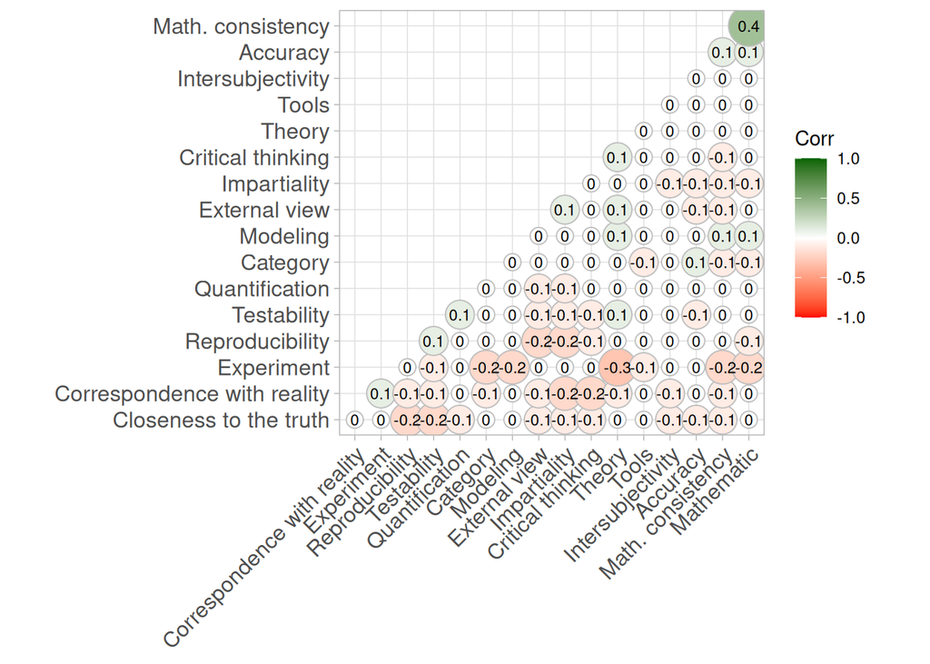

```r
# Korelogram
ggcorrplot(kor, method = 'circle', hc.order = TRUE, type ='lower',
           show.diag = FALSE, ggtheme = theme_light(), lab = TRUE, lab_size = 3,
           colors = c("red", "white", "darkgreen"), digits = 1)
```

[figure not shown]

```r
corrgram(kor, order="HC", lower.panel = NULL, upper.panel=panel.pie,
         col.regions=colorRampPalette(c("red", "white", "darkgreen")))
```

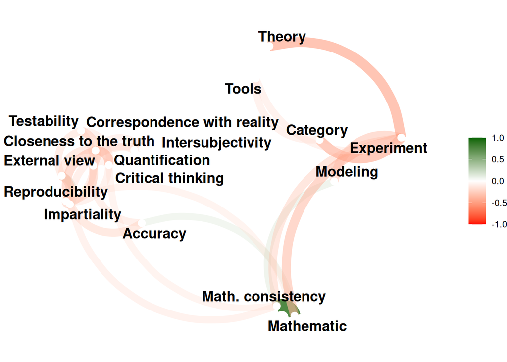

```r
network_plot((2 * kor), min_cor = 0.2, colours = c("red", "white", "darkgreen"))
```

Nic moc s ničím výrazně nekoreluje. Spíše jsou orelace negativní, tedy uvedu-li příslušnou charakteristiku, neuvedu spíš druhou.

## Faktorová analýza

```r
# Selekce  a příprava dat
soubor = select(data, starts_with('objekt_'), -objekt_diskut) %>%
  mutate_at(vars(starts_with('objekt_')),
            ~recode(., `Ne` = '0', `Ano` = '1')) %>%
  mutate_at(vars(starts_with('objekt_')),
            ~as.character(.)) %>%
  mutate_at(vars(starts_with('objekt_')),
            ~as.integer(.))

# Větší smysl má dělat to jen metodou hlavních komponent:
# soubor %>% factanal(factors = 6, rotation = "varimax")
print('Škálované řešení')
```

```
## [1] "Škálované řešení"
```

```r
skalovano = soubor %>% prcomp(scale. = TRUE)
skalovano
```

```
## Standard deviations (1, .., p=11):
##  [1] 1.2503505 1.1732196 1.0775230 1.0497773 1.0058353 0.9908026 0.9684618
##  [8] 0.9411981 0.9207089 0.9115323 0.5489340
##
## Rotation (n x k) = (11 x 11):
##                                       PC1         PC2         PC3         PC4
## objekt_vnejsi.pohled           -0.4513303 -0.16249758  0.02669464  0.23019012
## objekt_presnost                 0.2213583  0.04138768 -0.55878473  0.29226125
## objekt_matematicka.konzistence  0.1610000 -0.02234453 -0.45198953  0.39917887
## objekt_testovatelnost           0.3546218 -0.24607404  0.40951672  0.06232706
## objekt_nestrannost             -0.4904095 -0.16240996  0.24449758  0.29067474
## objekt_priblizeni.pravde       -0.2049944  0.52512127  0.06203257 -0.31750269
## objekt_shoda.s.realitou         0.1526642  0.61255902  0.10094588  0.03149668
## objekt_kvantifikace             0.1918856 -0.17463571  0.29944248  0.18017776
## objekt_intersubjektivita        0.1008831 -0.20787182 -0.16873906 -0.55583266
## objekt_kriticke.mysleni        -0.2210915 -0.35473976 -0.31133712 -0.40200640
## objekt_reprodukovatelnost       0.4403571 -0.18418299  0.16174639 -0.09514474
##                                        PC5         PC6          PC7
## objekt_vnejsi.pohled            0.03144284  0.11582533 -0.436925460
## objekt_presnost                -0.35663199 -0.11673216 -0.195110014
## objekt_matematicka.konzistence  0.56319593  0.15883625  0.318080704
## objekt_testovatelnost           0.16493666 -0.03194474  0.074361783
## objekt_nestrannost              0.08534903 -0.25529313 -0.002032231
## objekt_priblizeni.pravde        0.19079791 -0.01096070  0.404777361
## objekt_shoda.s.realitou        -0.22793352  0.13801852 -0.327381666
## objekt_kvantifikace            -0.26310680  0.71343079  0.176651045
## objekt_intersubjektivita        0.41138044  0.25751458 -0.489991594
## objekt_kriticke.mysleni        -0.43523397  0.05884675  0.348925718
## objekt_reprodukovatelnost      -0.06246247 -0.53254545 -0.015783152
##                                         PC8         PC9        PC10       PC11
## objekt_vnejsi.pohled           -0.100487170 -0.36648881 -0.54884260 -0.2554359
## objekt_presnost                 0.001805967  0.51802970 -0.22860823 -0.2283202
## objekt_matematicka.konzistence  0.005954056 -0.28638687  0.14059151 -0.2540248
## objekt_testovatelnost          -0.676001429  0.22935917 -0.12422737 -0.2886730
## objekt_nestrannost              0.211136356  0.34831127  0.44714178 -0.3880109
## objekt_priblizeni.pravde        0.108550145  0.22438780 -0.43564520 -0.3539498
## objekt_shoda.s.realitou        -0.172491969 -0.27506842  0.38736281 -0.3957718
## objekt_kvantifikace             0.399427764  0.09087153 -0.07809742 -0.1650419
## objekt_intersubjektivita        0.152230867  0.22393518  0.12588693 -0.2106680
## objekt_kriticke.mysleni        -0.240623670 -0.21986543  0.16415880 -0.3448317
## objekt_reprodukovatelnost       0.454041830 -0.32958980 -0.15048045 -0.3343122
```

```r
skalovano %>% summary()
```

```
## Importance of components:
##                           PC1    PC2    PC3    PC4     PC5     PC6     PC7
## Standard deviation     1.2504 1.1732 1.0775 1.0498 1.00584 0.99080 0.96846
## Proportion of Variance 0.1421 0.1251 0.1056 0.1002 0.09197 0.08924 0.08527
## Cumulative Proportion  0.1421 0.2673 0.3728 0.4730 0.56496 0.65421 0.73947
##                            PC8     PC9    PC10    PC11
## Standard deviation     0.94120 0.92071 0.91153 0.54893
## Proportion of Variance 0.08053 0.07706 0.07554 0.02739
## Cumulative Proportion  0.82001 0.89707 0.97261 1.00000
```

```r
# skalovano %>% plot()

print('Neškálované řešení')
```

```
## [1] "Neškálované řešení"
```

```r
neskalovano = soubor %>% prcomp(scale. = FALSE)
neskalovano
```

```
## Standard deviations (1, .., p=11):
##  [1] 0.5702301 0.5388040 0.4988295 0.4426984 0.4267296 0.3847710 0.3286278
##  [8] 0.2860563 0.2659440 0.2297203 0.1908909
##
## Rotation (n x k) = (11 x 11):
##                                        PC1         PC2          PC3         PC4
## objekt_vnejsi.pohled           -0.15329629 -0.02226637  0.029152321 -0.01896111
## objekt_presnost                 0.09370997  0.02540328 -0.089680603  0.03331784
## objekt_matematicka.konzistence  0.03112057  0.01284807 -0.001961485 -0.02188226
## objekt_testovatelnost           0.26526391  0.30489375  0.255969459 -0.76154396
## objekt_nestrannost             -0.63312576 -0.07951603  0.599218586  0.11136764
## objekt_priblizeni.pravde       -0.03650543 -0.39845746 -0.130006591  0.15408282
## objekt_shoda.s.realitou         0.36573432 -0.59453198 -0.143662751 -0.02556620
## objekt_kvantifikace             0.03151079  0.03486643  0.015596028 -0.04278040
## objekt_intersubjektivita        0.01993360  0.06864731 -0.048614305 -0.01949747
## objekt_kriticke.mysleni        -0.39031534  0.39314601 -0.688559472 -0.01022725
## objekt_reprodukovatelnost       0.45464981  0.47611163  0.228602219  0.61562128
##                                         PC5         PC6         PC7         PC8
## objekt_vnejsi.pohled           -0.017759396 -0.10989920 -0.35636799  0.63164298
## objekt_presnost                -0.133140297 -0.67386429  0.64306024 -0.04392845
## objekt_matematicka.konzistence  0.015980335 -0.21418968 -0.12591111  0.00230307
## objekt_testovatelnost           0.130982081  0.26351724  0.23996132  0.01504037
## objekt_nestrannost             -0.218866625  0.20200298  0.26413192 -0.15320654
## objekt_priblizeni.pravde        0.772472888  0.22732887  0.28802532 -0.01928356
## objekt_shoda.s.realitou        -0.538167956  0.35502950  0.11323307 -0.03899221
## objekt_kvantifikace            -0.016885443 -0.02860482 -0.07836746  0.02929313
## objekt_intersubjektivita        0.049654080 -0.10241161 -0.39698031 -0.75500680
## objekt_kriticke.mysleni        -0.165739789  0.33774581  0.20762059 -0.01315048
## objekt_reprodukovatelnost      -0.009195326  0.27313433  0.11684698  0.04934713
##                                        PC9        PC10      PC11
## objekt_vnejsi.pohled           -0.50422391 -0.26800923 0.3322050
## objekt_presnost                -0.24793806 -0.06645882 0.1680915
## objekt_matematicka.konzistence  0.69104401 -0.52014496 0.4339351
## objekt_testovatelnost          -0.10403699 -0.13568639 0.1325349
## objekt_nestrannost             -0.02554372 -0.08853752 0.1758585
## objekt_priblizeni.pravde       -0.09191390 -0.09217965 0.2249162
## objekt_shoda.s.realitou        -0.08266136 -0.12836319 0.1953323
## objekt_kvantifikace             0.12409596  0.74171306 0.6496746
## objekt_intersubjektivita       -0.39613215 -0.17466764 0.2532488
## objekt_kriticke.mysleni        -0.01517649 -0.09282102 0.1587583
## objekt_reprodukovatelnost      -0.08622700 -0.11276889 0.1563187
```

```r
neskalovano %>% summary()
```

```
## Importance of components:
##                           PC1    PC2    PC3    PC4    PC5     PC6     PC7
## Standard deviation     0.5702 0.5388 0.4988 0.4427 0.4267 0.38477 0.32863
## Proportion of Variance 0.1868 0.1668 0.1430 0.1126 0.1046 0.08508 0.06206
## Cumulative Proportion  0.1868 0.3537 0.4967 0.6093 0.7139 0.79901 0.86107
##                            PC8     PC9    PC10    PC11
## Standard deviation     0.28606 0.26594 0.22972 0.19089
## Proportion of Variance 0.04702 0.04064 0.03033 0.02094
## Cumulative Proportion  0.90809 0.94874 0.97906 1.00000
```

```r
# neskalovano %>% plot()
```

# Další výsledky

## Neobjektivita

### Vnímání objektivity

```r
for (i in c('neobj_nerepre', 'neobj_hacking', 'neobj_positiv', 'neobj_popular',
            'neobj_modmet', 'neobj_oversell', 'neobj_zbytecne', 'neobj_salam')) {
  vnimani.objektivity(i)
}
```

```
## [1] "Eukleidovská vzdálenost kategorií 'neobj_nerepre':"
##     celek   Ano
## Ano  2.06
## Ne  12.92 14.46
## [1] " "
## [1] "Vnímání objektivity dle kategorií 'neobj_nerepre':"
##                                celek  Ano   Ne p.hodnota
## objekt_vnejsi.pohled               9    9 10.7     0.744
## objekt_presnost                 14.8 14.8 11.9     0.575
## objekt_matematicka.konzistence   6.9  6.2  7.1     0.912
## objekt_testovatelnost             28   28 29.8      0.83
## objekt_nestrannost              47.8 49.2 45.2     0.558
## objekt_priblizeni.pravde        24.2 24.9 20.2      0.42
## objekt_shoda.s.realitou         34.8 35.2   31     0.505
## objekt_kvantifikace                5  4.7  7.1      0.46
## objekt_intersubjektivita         9.1  9.1  8.3     0.972
## objekt_kriticke.mysleni         40.1   41 29.8    0.06 +
## objekt_reprodukovatelnost       37.7 38.2 35.7     0.747
## Abs. počty:                      941  857   84
```

```
## [1] "Eukleidovská vzdálenost kategorií 'neobj_hacking':"
##     celek   Ano
## Ano  5.46
## Ne  28.52 31.54
## [1] " "
## [1] "Vnímání objektivity dle kategorií 'neobj_hacking':"
##                                celek  Ano   Ne p.hodnota
## objekt_vnejsi.pohled               9 10.2  4.3     0.577
## objekt_presnost                 14.8 12.5   13         1
## objekt_matematicka.konzistence   6.9  6.4  4.3         1
## objekt_testovatelnost             28   31 30.4         1
## objekt_nestrannost              47.8 47.8 47.8         1
## objekt_priblizeni.pravde        24.2 26.3 21.7     0.806
## objekt_shoda.s.realitou         34.8 33.8 39.1      0.76
## objekt_kvantifikace                5  5.5    0     0.497
## objekt_intersubjektivita         9.1  9.3  8.7         1
## objekt_kriticke.mysleni         40.1 42.9 17.4   0.027 *
## objekt_reprodukovatelnost       37.7 37.2 52.2     0.219
## Abs. počty:                      494  471   23
## [1] "Eukleidovská vzdálenost kategorií 'neobj_positiv':"
##     celek   Ano
## Ano  2.68
## Ne   9.02 11.49
## [1] " "
## [1] "Vnímání objektivity dle kategorií 'neobj_positiv':"
##                                celek  Ano   Ne p.hodnota
## objekt_vnejsi.pohled               9    9 10.1     0.745
## objekt_presnost                 14.8 14.8 14.3     0.961
## objekt_matematicka.konzistence   6.9    7  5.3     0.501
## objekt_testovatelnost             28 27.8 30.7     0.485
## objekt_nestrannost              47.8 48.9   46     0.535
## objekt_priblizeni.pravde        24.2 25.3 22.2     0.434
## objekt_shoda.s.realitou         34.8   34 36.5     0.572
## objekt_kvantifikace                5  5.1  5.3         1
## objekt_intersubjektivita         9.1   10  5.8       0.1
## objekt_kriticke.mysleni         40.1 40.7 38.1     0.566
## objekt_reprodukovatelnost       37.7   36 44.4   0.039 *
## Abs. počty:                      948  759  189
## [1] "Eukleidovská vzdálenost kategorií 'neobj_popular':"
##     celek  Ano
```

[output cut: 78 more lines]

```
## [1] " "
## [1] "Vnímání objektivity dle kategorií 'neobj_salam':"
##                                celek  Ano   Ne p.hodnota
## objekt_vnejsi.pohled               9  9.4  9.5         1
## objekt_presnost                 14.8 18.9 12.3  0.008 **
## objekt_matematicka.konzistence   6.9  7.7  6.9      0.75
## objekt_testovatelnost             28 26.1 30.2     0.188
## objekt_nestrannost              47.8 44.9 50.2     0.129
## objekt_priblizeni.pravde        24.2 22.6 25.7     0.313
## objekt_shoda.s.realitou         34.8 35.2 34.6     0.893
## objekt_kvantifikace                5  4.5  5.3     0.655
## objekt_intersubjektivita         9.1 10.2  8.3     0.391
## objekt_kriticke.mysleni         40.1 44.2 37.2   0.038 *
## objekt_reprodukovatelnost       37.7 40.4   37     0.315
## Abs. počty:                      909  403  506
```

### Diskuse o objektivitě

```r
for (i in c('neobj_nerepre', 'neobj_hacking', 'neobj_positiv', 'neobj_popular',
            'neobj_modmet', 'neobj_oversell', 'neobj_zbytecne', 'neobj_salam')) {
  diskuse.objektivita(i)
}
```

```
## [1] "Eukleidovská vzdálenost kategorií 'neobj_nerepre':"
##     celek  Ano
## Ano  1.45
## Ne   7.34 8.32
## [1] " "
## [1] "Diskuse o objektivitě dle kategorií 'neobj_nerepre':"
##             celek   Ano   Ne
## Někdy        40.0  40.7 41.7
## Nikdy        15.1  13.9 20.2
## Velmi často   6.6   7.0  2.4
## Zřídka       38.4  38.4 35.7
## Abs. počty: 941.0 857.0 84.0
##
##  Pearson's Chi-squared test
##
## data:  x
## X-squared = 4.7747, df = 3, p-value = 0.1891
##
## [1] "Eukleidovská vzdálenost kategorií 'neobj_hacking':"
##     celek   Ano
## Ano  5.33
## Ne  20.91 18.67
## [1] " "
## [1] "Diskuse o objektivitě dle kategorií 'neobj_hacking':"
##             celek   Ano   Ne
## Někdy        40.0  43.1 52.2
## Nikdy        15.1  11.5 17.4
## Velmi často   6.6   8.5  8.7
## Zřídka       38.4  36.9 21.7
## Abs. počty: 494.0 471.0 23.0
```

```
##
##  Pearson's Chi-squared test
##
## data:  x
## X-squared = 2.4708, df = 3, p-value = 0.4806
##
## [1] "Eukleidovská vzdálenost kategorií 'neobj_positiv':"
##     celek  Ano
## Ano  1.09
## Ne   3.17 4.13
## [1] " "
## [1] "Diskuse o objektivitě dle kategorií 'neobj_positiv':"
##             celek   Ano    Ne
## Někdy        40.0  40.7  38.1
## Nikdy        15.1  14.6  17.5
## Velmi často   6.6   6.9   5.8
## Zřídka       38.4  37.8  38.6
## Abs. počty: 948.0 759.0 189.0
##
##  Pearson's Chi-squared test
##
## data:  x
## X-squared = 1.3271, df = 3, p-value = 0.7227
##
## [1] "Eukleidovská vzdálenost kategorií 'neobj_popular':"
##     celek  Ano
## Ano  5.43
## Ne   1.81 7.24
## [1] " "
## [1] "Diskuse o objektivitě dle kategorií 'neobj_popular':"
##             celek   Ano    Ne
## Někdy        40.0  41.6  39.5
## Nikdy        15.1  13.8  15.5
## Velmi často   6.6  10.0   5.4
## Zřídka       38.4  34.7  39.6
## Abs. počty: 880.0 320.0 560.0
##
##  Pearson's Chi-squared test
##
## data:  x
```

[output cut: 58 more lines]

```
## Ano 10.49
## Ne   7.29 17.77
## [1] " "
## [1] "Diskuse o objektivitě dle kategorií 'neobj_salam':"
##             celek   Ano    Ne
## Někdy        40.0  44.2  36.8
## Nikdy        15.1  12.2  17.2
## Velmi často   6.6  12.4   2.8
## Zřídka       38.4  31.3  43.3
## Abs. počty: 909.0 403.0 506.0
##
##  Pearson's Chi-squared test
##
## data:  x
## X-squared = 45.02, df = 3, p-value = 9.163e-10
```

## Vlastnosti oboru

### Vnímání objektivity

```r
for (i in c('obor_dotovany', 'obor_konkuren', 'obor_tlak', 'obor_rychly', 'obor_priliv', 'obor_publikac', 'obor_medializ', 'obor_verejnos', 'obor_komplexn', 'obor_mensi')) {
  vnimani.objektivity(i)
}
```

```
## [1] "Eukleidovská vzdálenost kategorií 'obor_dotovany':"
##              celek Rozhodně ano Rozhodně ne Spíše ano
## Rozhodně ano 23.38
## Rozhodně ne   7.37        26.79
## Spíše ano     7.84        28.19       11.05
## Spíše ne      4.41        22.42       10.08     11.20
## [1] " "
## [1] "Vnímání objektivity dle kategorií 'obor_dotovany':"
##                                celek Rozhodně.ano Rozhodně.ne Spíše.ano
## objekt_vnejsi.pohled               9          1.8         9.6      10.1
## objekt_presnost                 14.8         23.6        16.1      12.2
## objekt_matematicka.konzistence   6.9          3.6         9.6       4.2
## objekt_testovatelnost             28         32.7        28.4      28.3
## objekt_nestrannost              47.8         41.8        43.6      48.5
## objekt_priblizeni.pravde        24.2         27.3        24.8      20.7
## objekt_shoda.s.realitou         34.8         38.2        32.6        35
## objekt_kvantifikace                5            0         4.6       6.3
## objekt_intersubjektivita         9.1         12.7         8.7       9.7
## objekt_kriticke.mysleni         40.1         23.6        44.5      44.3
## objekt_reprodukovatelnost       37.7         41.8        36.2      41.4
## Abs. počty:                      968           55         218       237
##                                Spíše.ne p.hodnota
## objekt_vnejsi.pohled                7.9     0.205
## objekt_presnost                    14.2     0.167
## objekt_matematicka.konzistence      7.6   0.095 +
## objekt_testovatelnost              27.3     0.862
## objekt_nestrannost                 48.7     0.501
## objekt_priblizeni.pravde           26.4     0.393
## objekt_shoda.s.realitou            36.9     0.704
## objekt_kvantifikace                   5     0.275
## objekt_intersubjektivita            8.1     0.665
## objekt_kriticke.mysleni              38   0.014 *
## objekt_reprodukovatelnost          36.5     0.529
## Abs. počty:                         458
```

```
## [1] "Eukleidovská vzdálenost kategorií 'obor_konkuren':"
##              celek Rozhodně ano Rozhodně ne Spíše ano
## Rozhodně ano  6.68
## Rozhodně ne  25.86        26.66
## Spíše ano     3.66         6.93       26.32
## Spíše ne      9.44        14.67       30.97     12.31
## [1] " "
## [1] "Vnímání objektivity dle kategorií 'obor_konkuren':"
##                                celek Rozhodně.ano Rozhodně.ne Spíše.ano
## objekt_vnejsi.pohled               9          7.1        18.2         9
## objekt_presnost                 14.8         15.2        27.3      14.6
## objekt_matematicka.konzistence   6.9          4.9           3       6.9
## objekt_testovatelnost             28         30.8        21.2      28.4
## objekt_nestrannost              47.8         44.6        36.4      47.5
## objekt_priblizeni.pravde        24.2         24.1        15.2      25.2
## objekt_shoda.s.realitou         34.8         33.9        33.3      36.6
## objekt_kvantifikace                5            4           3       4.7
## objekt_intersubjektivita         9.1         10.7         9.1       7.3
## objekt_kriticke.mysleni         40.1         40.2        51.5      41.5
## objekt_reprodukovatelnost       37.7         41.5        33.3      39.6
## Abs. počty:                     1001          224          33       465
##                                Spíše.ne p.hodnota
## objekt_vnejsi.pohled                8.6     0.218
## objekt_presnost                    12.9     0.177
## objekt_matematicka.konzistence      7.9      0.47
## objekt_testovatelnost              26.9     0.618
## objekt_nestrannost                 52.3     0.177
## objekt_priblizeni.pravde           25.1      0.63
## objekt_shoda.s.realitou              33     0.766
## objekt_kvantifikace                 6.5     0.565
## objekt_intersubjektivita           10.8      0.33
## objekt_kriticke.mysleni            36.2     0.268
## objekt_reprodukovatelnost          31.5   0.077 +
## Abs. počty:                         279
```

```
## [1] "Eukleidovská vzdálenost kategorií 'obor_tlak':"
##              celek Rozhodně ano Rozhodně ne Spíše ano
## Rozhodně ano  6.79
## Rozhodně ne  21.85        24.16
## Spíše ano     4.13         9.37       22.12
## Spíše ne      6.03        10.69       23.01      9.18
## [1] " "
## [1] "Vnímání objektivity dle kategorií 'obor_tlak':"
##                                celek Rozhodně.ano Rozhodně.ne Spíše.ano
## objekt_vnejsi.pohled               9          7.7         9.1       8.4
## objekt_presnost                 14.8           15        13.6      16.1
## objekt_matematicka.konzistence   6.9          4.3           0       8.4
## objekt_testovatelnost             28         27.4        22.7      28.2
## objekt_nestrannost              47.8         48.7        40.9      46.2
## objekt_priblizeni.pravde        24.2         28.2        22.7      23.6
## objekt_shoda.s.realitou         34.8         33.3        40.9      35.6
## objekt_kvantifikace                5          3.4         4.5       6.1
## objekt_intersubjektivita         9.1          5.6         9.1      10.3
## objekt_kriticke.mysleni         40.1         41.9        22.7      40.6
## objekt_reprodukovatelnost       37.7           38        40.9      40.2
## Abs. počty:                      992          234          22       478
##                                Spíše.ne p.hodnota
## objekt_vnejsi.pohled               10.1     0.804
## objekt_presnost                    12.4     0.604
## objekt_matematicka.konzistence        7     0.123
## objekt_testovatelnost              28.3     0.945
## objekt_nestrannost                   50     0.691
## objekt_priblizeni.pravde           21.7     0.387
## objekt_shoda.s.realitou            34.5      0.87
## objekt_kvantifikace                 4.7     0.488
## objekt_intersubjektivita           10.1     0.201
## objekt_kriticke.mysleni            39.1     0.359
## objekt_reprodukovatelnost          33.7     0.386
## Abs. počty:                         258
```

```
## [1] "Eukleidovská vzdálenost kategorií 'obor_rychly':"
##              celek Rozhodně ano Rozhodně ne Spíše ano
## Rozhodně ano 12.59
## Rozhodně ne  22.72        24.62
## Spíše ano     9.02        19.80       29.20
## Spíše ne      4.34        13.80       24.43     10.76
## [1] " "
## [1] "Vnímání objektivity dle kategorií 'obor_rychly':"
##                                celek Rozhodně.ano Rozhodně.ne Spíše.ano
## objekt_vnejsi.pohled               9          9.7        15.9       8.8
## objekt_presnost                 14.8           16        22.7        14
## objekt_matematicka.konzistence   6.9          5.6        18.2       4.7
## objekt_testovatelnost             28         27.8        26.1      29.2
## objekt_nestrannost              47.8         41.7        43.2      49.1
## objekt_priblizeni.pravde        24.2         29.9        21.6      21.9
## objekt_shoda.s.realitou         34.8         39.6        30.7      32.2
## objekt_kvantifikace                5          3.5         5.7       5.8
## objekt_intersubjektivita         9.1         14.6           8       7.9
## objekt_kriticke.mysleni         40.1         36.1          42      42.4
## objekt_reprodukovatelnost       37.7           34        22.7        45
## Abs. počty:                      996          144          88       342
##                                Spíše.ne  p.hodnota
## objekt_vnejsi.pohled                6.9    0.053 +
## objekt_presnost                    13.5      0.155
## objekt_matematicka.konzistence      7.1 <0.001 ***
## objekt_testovatelnost              27.7      0.935
## objekt_nestrannost                 50.2      0.246
## objekt_priblizeni.pravde           23.7      0.282
## objekt_shoda.s.realitou            36.5      0.299
## objekt_kvantifikace                   5       0.74
## objekt_intersubjektivita            8.5      0.106
## objekt_kriticke.mysleni            38.4      0.509
## objekt_reprodukovatelnost            37   0.001 **
## Abs. počty:                         422
```

```
## [1] "Eukleidovská vzdálenost kategorií 'obor_priliv':"
##              celek Rozhodně ano Rozhodně ne Spíše ano
## Rozhodně ano 17.68
## Rozhodně ne   8.24        21.52
## Spíše ano     7.11        22.87       11.60
## Spíše ne      2.94        16.75       10.38      9.05
## [1] " "
## [1] "Vnímání objektivity dle kategorií 'obor_priliv':"
##                                celek Rozhodně.ano Rozhodně.ne Spíše.ano
## objekt_vnejsi.pohled               9         11.6          11       6.8
## objekt_presnost                 14.8         25.6          13      13.5
## objekt_matematicka.konzistence   6.9          9.3         6.5         5
## objekt_testovatelnost             28         30.2        26.5      27.5
## objekt_nestrannost              47.8         53.5          46      47.7
## objekt_priblizeni.pravde        24.2         18.6        24.5      28.8
## objekt_shoda.s.realitou         34.8         34.9        39.5      32.4
## objekt_kvantifikace                5          2.3           6       3.6
## objekt_intersubjektivita         9.1         11.6           7       9.5
## objekt_kriticke.mysleni         40.1         30.2        39.5      43.2
## objekt_reprodukovatelnost       37.7         39.5        32.5      36.5
## Abs. počty:                      970           43         200       222
##                                Spíše.ne p.hodnota
## objekt_vnejsi.pohled                8.9     0.438
## objekt_presnost                      15     0.186
## objekt_matematicka.konzistence      7.7     0.518
## objekt_testovatelnost              28.5     0.935
## objekt_nestrannost                 47.7     0.848
## objekt_priblizeni.pravde             23     0.296
## objekt_shoda.s.realitou            34.5     0.478
## objekt_kvantifikace                 5.5     0.519
## objekt_intersubjektivita            9.7     0.651
## objekt_kriticke.mysleni            39.6     0.434
## objekt_reprodukovatelnost            40     0.303
## Abs. počty:                         505
```

```
## [1] "Eukleidovská vzdálenost kategorií 'obor_publikac':"
##              celek Rozhodně ano Rozhodně ne Spíše ano
## Rozhodně ano  7.39
## Rozhodně ne  26.17        30.47
## Spíše ano     3.91         9.20       26.98
## Spíše ne      7.61        12.66       27.70     10.29
## [1] " "
## [1] "Vnímání objektivity dle kategorií 'obor_publikac':"
##                                celek Rozhodně.ano Rozhodně.ne Spíše.ano
## objekt_vnejsi.pohled               9          5.9        10.2       9.7
## objekt_presnost                 14.8         16.1         6.1      14.3
## objekt_matematicka.konzistence   6.9          4.2        12.2       7.9
## objekt_testovatelnost             28         27.5        12.2      29.5
## objekt_nestrannost              47.8         46.6        57.1      46.8
## objekt_priblizeni.pravde        24.2         25.4        18.4      25.1
## objekt_shoda.s.realitou         34.8         33.5        44.9      36.3
## objekt_kvantifikace                5          4.7         6.1         4
## objekt_intersubjektivita         9.1         10.2        14.3       7.9
## objekt_kriticke.mysleni         40.1         45.3        32.7      40.7
## objekt_reprodukovatelnost       37.7         39.4        32.7      35.6
## Abs. počty:                      995          236          49       455
##                                Spíše.ne p.hodnota
## objekt_vnejsi.pohled                 11     0.242
## objekt_presnost                    16.5     0.274
## objekt_matematicka.konzistence      6.7     0.138
## objekt_testovatelnost              28.6   0.086 +
## objekt_nestrannost                 47.8     0.573
## objekt_priblizeni.pravde           21.6     0.528
## objekt_shoda.s.realitou            32.2     0.311
## objekt_kvantifikace                 7.1     0.322
## objekt_intersubjektivita              9     0.439
## objekt_kriticke.mysleni            35.3   0.096 +
## objekt_reprodukovatelnost          40.8     0.439
## Abs. počty:                         255
```

```
## [1] "Eukleidovská vzdálenost kategorií 'obor_medializ':"
##              celek Rozhodně ano Rozhodně ne Spíše ano
## Rozhodně ano 18.17
## Rozhodně ne  17.39        21.72
## Spíše ano     8.44        21.22       23.09
## Spíše ne      6.02        21.97       20.60     12.31
## [1] " "
## [1] "Vnímání objektivity dle kategorií 'obor_medializ':"
##                                celek Rozhodně.ano Rozhodně.ne Spíše.ano
## objekt_vnejsi.pohled               9          8.5        11.6       8.6
## objekt_presnost                 14.8         20.7        19.8      14.2
## objekt_matematicka.konzistence   6.9          6.1        16.5       2.5
## objekt_testovatelnost             28           28          19      31.7
## objekt_nestrannost              47.8         35.4        46.3        48
## objekt_priblizeni.pravde        24.2         26.8        24.8        28
## objekt_shoda.s.realitou         34.8         37.8        39.7      34.5
## objekt_kvantifikace                5          3.7         2.5       4.9
## objekt_intersubjektivita         9.1          8.5         9.9       5.5
## objekt_kriticke.mysleni         40.1         29.3        36.4      42.8
## objekt_reprodukovatelnost       37.7         40.2        30.6        36
## Abs. počty:                     1007           82         121       325
##                                Spíše.ne  p.hodnota
## objekt_vnejsi.pohled                8.4      0.731
## objekt_presnost                    12.9      0.105
## objekt_matematicka.konzistence      7.5 <0.001 ***
## objekt_testovatelnost                28    0.071 +
## objekt_nestrannost                 49.7      0.119
## objekt_priblizeni.pravde           21.1      0.144
## objekt_shoda.s.realitou            33.4      0.569
## objekt_kvantifikace                 6.1       0.39
## objekt_intersubjektivita           11.5    0.039 *
## objekt_kriticke.mysleni            41.5      0.109
## objekt_reprodukovatelnost          40.5      0.185
## Abs. počty:                         479
```

```
## [1] "Eukleidovská vzdálenost kategorií 'obor_verejnos':"
##              celek Rozhodně ano Rozhodně ne Spíše ano
## Rozhodně ano 18.09
## Rozhodně ne  12.18        21.62
## Spíše ano    10.09        22.06       21.10
## Spíše ne      3.09        19.28       13.75     10.51
## [1] " "
## [1] "Vnímání objektivity dle kategorií 'obor_verejnos':"
##                                celek Rozhodně.ano Rozhodně.ne Spíše.ano
## objekt_vnejsi.pohled               9          6.7         6.7       9.7
## objekt_presnost                 14.8         13.3        13.4        13
## objekt_matematicka.konzistence   6.9          8.3        13.4       2.5
## objekt_testovatelnost             28         23.3        28.4      28.6
## objekt_nestrannost              47.8           40          50      50.4
## objekt_priblizeni.pravde        24.2           30        21.6      25.6
## objekt_shoda.s.realitou         34.8           30        35.1      34.9
## objekt_kvantifikace                5          1.7         6.2       3.4
## objekt_intersubjektivita         9.1           15         8.2       7.6
## objekt_kriticke.mysleni         40.1         36.7        30.9      47.9
## objekt_reprodukovatelnost       37.7         26.7        37.6      35.7
## Abs. počty:                      944           60         194       238
##                                Spíše.ne  p.hodnota
## objekt_vnejsi.pohled                9.5       0.59
## objekt_presnost                    15.5      0.799
## objekt_matematicka.konzistence      5.5 <0.001 ***
## objekt_testovatelnost              28.1      0.873
## objekt_nestrannost                 47.1      0.468
## objekt_priblizeni.pravde           24.8      0.575
## objekt_shoda.s.realitou            36.3      0.813
## objekt_kvantifikace                 5.8      0.275
## objekt_intersubjektivita             10      0.303
## objekt_kriticke.mysleni            40.3   0.004 **
## objekt_reprodukovatelnost          39.2       0.28
## Abs. počty:                         452
```

```
## [1] "Eukleidovská vzdálenost kategorií 'obor_komplexn':"
##              celek Rozhodně ano Rozhodně ne Spíše ano
## Rozhodně ano  4.97
## Rozhodně ne  25.12        24.09
## Spíše ano     4.49         8.32       27.79
## Spíše ne      9.55        12.67       27.76     11.97
## [1] " "
## [1] "Vnímání objektivity dle kategorií 'obor_komplexn':"
##                                celek Rozhodně.ano Rozhodně.ne Spíše.ano
## objekt_vnejsi.pohled               9          9.1         4.3       8.8
## objekt_presnost                 14.8         13.7        21.7      15.1
## objekt_matematicka.konzistence   6.9          7.4         8.7       6.1
## objekt_testovatelnost             28         29.9        17.4      29.8
## objekt_nestrannost              47.8         46.4        39.1      47.8
## objekt_priblizeni.pravde        24.2         26.2        21.7      22.6
## objekt_shoda.s.realitou         34.8         33.6        34.8      37.5
## objekt_kvantifikace                5          4.6         8.7       4.8
## objekt_intersubjektivita         9.1            8         8.7       9.6
## objekt_kriticke.mysleni         40.1         39.3        30.4      41.2
## objekt_reprodukovatelnost       37.7         34.5        21.7      39.9
## Abs. počty:                     1000          351          23       456
##                                Spíše.ne p.hodnota
## objekt_vnejsi.pohled                 10     0.837
## objekt_presnost                    13.5     0.696
## objekt_matematicka.konzistence      5.9     0.841
## objekt_testovatelnost              21.8     0.116
## objekt_nestrannost                 52.4     0.501
## objekt_priblizeni.pravde           23.5     0.677
## objekt_shoda.s.realitou            30.6     0.391
## objekt_kvantifikace                 5.9     0.774
## objekt_intersubjektivita            8.8     0.876
## objekt_kriticke.mysleni            39.4      0.74
## objekt_reprodukovatelnost          40.6     0.132
## Abs. počty:                         170
```

```
## [1] "Eukleidovská vzdálenost kategorií 'obor_mensi':"
##              celek Rozhodně ano Rozhodně ne Spíše ano
## Rozhodně ano 20.06
## Rozhodně ne   6.01        23.59
## Spíše ano     4.82        21.65        8.27
## Spíše ne      6.88        23.71       10.50      9.61
## [1] " "
## [1] "Vnímání objektivity dle kategorií 'obor_mensi':"
##                                celek Rozhodně.ano Rozhodně.ne Spíše.ano
## objekt_vnejsi.pohled               9         10.4         8.6      10.2
## objekt_presnost                 14.8         10.4        13.2      15.1
## objekt_matematicka.konzistence   6.9         12.5           5       7.9
## objekt_testovatelnost             28         21.9        28.8      26.2
## objekt_nestrannost              47.8         60.4        44.7      47.9
## objekt_priblizeni.pravde        24.2           25        23.5      24.3
## objekt_shoda.s.realitou         34.8           25        33.1        37
## objekt_kvantifikace                5          4.2         5.6       4.9
## objekt_intersubjektivita         9.1          9.4         9.6       8.9
## objekt_kriticke.mysleni         40.1         39.6        42.1      37.7
## objekt_reprodukovatelnost       37.7         30.2        41.1      40.3
## Abs. počty:                      976           96         302       305
##                                Spíše.ne p.hodnota
## objekt_vnejsi.pohled                8.4     0.842
## objekt_presnost                    17.9     0.241
## objekt_matematicka.konzistence      5.5   0.049 *
## objekt_testovatelnost              31.9     0.226
## objekt_nestrannost                 47.3   0.063 +
## objekt_priblizeni.pravde           23.8     0.991
## objekt_shoda.s.realitou            37.7     0.104
## objekt_kvantifikace                 4.4     0.896
## objekt_intersubjektivita            8.8     0.985
## objekt_kriticke.mysleni            40.3     0.749
## objekt_reprodukovatelnost          34.4     0.119
## Abs. počty:                         273
```

### Diskuse o objektivitě

```r
for (i in c('obor_dotovany', 'obor_konkuren', 'obor_tlak', 'obor_rychly', 'obor_priliv', 'obor_publikac', 'obor_medializ', 'obor_verejnos', 'obor_komplexn', 'obor_mensi')) {
  diskuse.objektivita(i)
}
```

```
## [1] "Eukleidovská vzdálenost kategorií 'obor_dotovany':"
##              celek Rozhodně ano Rozhodně ne Spíše ano
## Rozhodně ano 13.16
## Rozhodně ne   2.86        14.82
## Spíše ano     4.41        12.04        6.97
## Spíše ne      2.57        13.26        1.62      6.39
## [1] " "
## [1] "Diskuse o objektivitě dle kategorií 'obor_dotovany':"
##             celek Rozhodně ano Rozhodně ne Spíše ano Spíše ne
## Někdy        40.0         41.8        41.3      39.7     41.7
## Nikdy        15.1         10.9        13.8      17.7     13.3
## Velmi často   6.6         16.4         5.0       7.6      6.1
## Zřídka       38.4         30.9        39.9      35.0     38.9
## Abs. počty: 968.0         55.0       218.0     237.0    458.0
```

```
##
##  Pearson's Chi-squared test
##
## data:  x
## X-squared = 13.358, df = 9, p-value = 0.1471
##
## [1] "Eukleidovská vzdálenost kategorií 'obor_konkuren':"
##              celek Rozhodně ano Rozhodně ne Spíše ano
## Rozhodně ano 11.97
## Rozhodně ne  17.39        27.98
## Spíše ano     2.87        10.68       19.61
## Spíše ne      9.67        21.36       11.41     11.97
## [1] " "
## [1] "Diskuse o objektivitě dle kategorií 'obor_konkuren':"
##              celek Rozhodně ano Rozhodně ne Spíše ano Spíše ne
## Někdy         40.0         48.7        30.3      41.9     31.9
## Nikdy         15.1         11.6        27.3      13.1     18.6
## Velmi často    6.6          8.5         0.0       6.0      7.2
## Zřídka        38.4         31.2        42.4      38.9     42.3
## Abs. počty: 1001.0        224.0        33.0     465.0    279.0
```

```
##
##  Pearson's Chi-squared test
##
## data:  x
## X-squared = 26.547, df = 9, p-value = 0.001662
##
## [1] "Eukleidovská vzdálenost kategorií 'obor_tlak':"
##              celek Rozhodně ano Rozhodně ne Spíše ano
## Rozhodně ano  8.54
## Rozhodně ne  21.76        30.11
## Spíše ano     5.14         7.26       25.37
## Spíše ne     11.76        19.10       14.62     16.55
## [1] " "
## [1] "Diskuse o objektivitě dle kategorií 'obor_tlak':"
##             celek Rozhodně ano Rozhodně ne Spíše ano Spíše ne
## Někdy        40.0         44.0        27.3      44.4     31.0
## Nikdy        15.1         12.8        18.2      13.2     21.7
## Velmi často   6.6         10.7         0.0       5.2      5.4
## Zřídka       38.4         32.5        54.5      37.2     41.9
## Abs. počty: 992.0        234.0        22.0     478.0    258.0
```

```
##
##  Pearson's Chi-squared test
##
## data:  x
## X-squared = 32.47, df = 9, p-value = 0.0001651
##
## [1] "Eukleidovská vzdálenost kategorií 'obor_rychly':"
##              celek Rozhodně ano Rozhodně ne Spíše ano
## Rozhodně ano  7.69
## Rozhodně ne  11.34        16.39
## Spíše ano     6.61         4.67       17.06
## Spíše ne      5.74        13.30        9.99     11.99
## [1] " "
## [1] "Diskuse o objektivitě dle kategorií 'obor_rychly':"
##             celek Rozhodně ano Rozhodně ne Spíše ano Spíše ne
## Někdy        40.0         43.8        30.7      45.3     36.7
## Nikdy        15.1         11.8        20.5      13.5     16.4
## Velmi často   6.6         10.4        10.2       6.4      4.5
## Zřídka       38.4         34.0        38.6      34.8     42.4
## Abs. počty: 996.0        144.0        88.0     342.0    422.0
##
##  Pearson's Chi-squared test
##
## data:  x
## X-squared = 21.201, df = 9, p-value = 0.01179
##
## [1] "Eukleidovská vzdálenost kategorií 'obor_priliv':"
##              celek Rozhodně ano Rozhodně ne Spíše ano
## Rozhodně ano 14.06
## Rozhodně ne  12.17        21.94
## Spíše ano    11.28        13.93       23.43
## Spíše ne      2.06        15.93       11.03     12.73
## [1] " "
## [1] "Diskuse o objektivitě dle kategorií 'obor_priliv':"
##             celek Rozhodně ano Rozhodně ne Spíše ano Spíše ne
## Někdy        40.0         37.2        31.5      47.7     39.8
## Nikdy        15.1         11.6        20.5      10.8     15.2
## Velmi často   6.6         18.6         3.5       9.5      5.1
## Zřídka       38.4         32.6        44.5      32.0     39.8
## Abs. počty: 970.0         43.0       200.0     222.0    505.0
```

```
##
##  Pearson's Chi-squared test
##
## data:  x
## X-squared = 36, df = 9, p-value = 3.965e-05
##
## [1] "Eukleidovská vzdálenost kategorií 'obor_publikac':"
##              celek Rozhodně ano Rozhodně ne Spíše ano
## Rozhodně ano  7.58
## Rozhodně ne   8.58        12.75
## Spíše ano     4.19         4.37       10.45
## Spíše ne     11.99        19.54       13.38     15.91
## [1] " "
## [1] "Diskuse o objektivitě dle kategorií 'obor_publikac':"
##             celek Rozhodně ano Rozhodně ne Spíše ano Spíše ne
## Někdy        40.0         44.9        34.7      43.1     32.2
## Nikdy        15.1         12.3        12.2      12.5     20.4
## Velmi často   6.6          8.9        12.2       7.0      2.7
## Zřídka       38.4         33.9        40.8      37.4     44.7
## Abs. počty: 995.0        236.0        49.0     455.0    255.0
```

```
##
##  Pearson's Chi-squared test
##
## data:  x
## X-squared = 29.137, df = 9, p-value = 0.0006145
##
## [1] "Eukleidovská vzdálenost kategorií 'obor_medializ':"
##              celek Rozhodně ano Rozhodně ne Spíše ano
## Rozhodně ano 12.13
## Rozhodně ne  10.83        19.13
## Spíše ano     3.86         9.86       13.89
## Spíše ne      3.31        14.83       11.54      6.40
## [1] " "
## [1] "Diskuse o objektivitě dle kategorií 'obor_medializ':"
##              celek Rozhodně ano Rozhodně ne Spíše ano Spíše ne
## Někdy         40.0         43.9        31.4      41.5     40.7
## Nikdy         15.1         13.4        21.5      12.3     15.7
## Velmi často    6.6         13.4         7.4       8.6      3.8
## Zřídka        38.4         29.3        39.7      37.5     39.9
## Abs. počty: 1007.0         82.0       121.0     325.0    479.0
##
##  Pearson's Chi-squared test
##
## data:  x
## X-squared = 24.012, df = 9, p-value = 0.004282
##
## [1] "Eukleidovská vzdálenost kategorií 'obor_verejnos':"
##              celek Rozhodně ano Rozhodně ne Spíše ano
## Rozhodně ano 21.97
## Rozhodně ne   6.88        28.19
## Spíše ano     4.05        18.49       10.92
## Spíše ne      2.21        22.46        7.51      4.22
## [1] " "
## [1] "Diskuse o objektivitě dle kategorií 'obor_verejnos':"
##             celek Rozhodně ano Rozhodně ne Spíše ano Spíše ne
## Někdy        40.0         38.3        38.1      41.2     41.8
## Nikdy        15.1          6.7        19.6      12.6     15.0
## Velmi často   6.6         25.0         2.1       9.2      5.8
## Zřídka       38.4         30.0        40.2      37.0     37.4
## Abs. počty: 944.0         60.0       194.0     238.0    452.0
```

```
##
##  Pearson's Chi-squared test
##
## data:  x
## X-squared = 45.032, df = 9, p-value = 9.102e-07
##
## [1] "Eukleidovská vzdálenost kategorií 'obor_komplexn':"
##              celek Rozhodně ano Rozhodně ne Spíše ano
## Rozhodně ano  7.27
## Rozhodně ne  26.27        33.10
## Spíše ano     2.56         8.03       27.00
## Spíše ne     10.96        17.02       17.36     12.52
## [1] " "
## [1] "Diskuse o objektivitě dle kategorií 'obor_komplexn':"
##              celek Rozhodně ano Rozhodně ne Spíše ano Spíše ne
## Někdy         40.0         43.3        21.7      41.4     32.9
## Nikdy         15.1         12.8        26.1      13.8     22.9
## Velmi často    6.6         10.3         0.0       5.3      4.1
## Zřídka        38.4         33.6        52.2      39.5     40.0
## Abs. počty: 1000.0        351.0        23.0     456.0    170.0
```

```
##
##  Pearson's Chi-squared test
##
## data:  x
## X-squared = 30.201, df = 9, p-value = 0.0004055
##
## [1] "Eukleidovská vzdálenost kategorií 'obor_mensi':"
##              celek Rozhodně ano Rozhodně ne Spíše ano
## Rozhodně ano  2.67
## Rozhodně ne   1.52         3.56
## Spíše ano     2.49         4.92        2.26
## Spíše ne      2.59         0.35        3.52      4.94
## [1] " "
## [1] "Diskuse o objektivitě dle kategorií 'obor_mensi':"
##             celek Rozhodně ano Rozhodně ne Spíše ano Spíše ne
## Někdy        40.0         40.6        40.1      40.7     40.3
## Nikdy        15.1         14.6        16.2      15.1     14.7
## Velmi často   6.6          8.3         5.6       4.6      8.4
## Zřídka       38.4         36.5        38.1      39.7     36.6
## Abs. počty: 976.0         96.0       302.0     305.0    273.0
##
##  Pearson's Chi-squared test
##
## data:  x
## X-squared = 4.8988, df = 9, p-value = 0.843
```

## Finance

### Vnímání objektivity

```r
for (i in c('financ_vliv', 'financ_zajisti.objektivitu', 'financ_neduvera', 'financ_zajisti.nezavislost')) {
  vnimani.objektivity(i)
}
```

```
## [1] "Eukleidovská vzdálenost kategorií 'financ_vliv':"
##             celek Někdy Nikdy Velmi často  Vždy
## Někdy        9.05
## Nikdy       56.38 56.35
## Velmi často  3.97 11.62 56.90
## Vždy        13.79 21.75 60.41       14.03
## Zřídka      11.95 17.27 59.89       13.51 15.15
## [1] " "
## [1] "Vnímání objektivity dle kategorií 'financ_vliv':"
##                                celek Někdy Nikdy Velmi.často Vždy Zřídka
## objekt_vnejsi.pohled               9   8.7     0         9.7  7.7   10.3
## objekt_presnost                 14.8  14.8     0        14.7 15.4   20.7
## objekt_matematicka.konzistence   6.9   9.3     0         6.4  3.8    8.6
## objekt_testovatelnost             28  31.2     0        26.4 26.2   29.3
## objekt_nestrannost              47.8  44.7  33.3        49.6 46.2   51.7
## objekt_priblizeni.pravde        24.2  23.5     0        23.6 28.5   22.4
## objekt_shoda.s.realitou         34.8  33.4  33.3        35.5 34.6   32.8
## objekt_kvantifikace                5   4.2  33.3         4.3  6.9    6.9
## objekt_intersubjektivita         9.1  11.6     0         9.3  6.2    6.9
## objekt_kriticke.mysleni         40.1  34.4  22.2        42.4 49.2   39.7
## objekt_reprodukovatelnost       37.7  41.5  44.4        39.3   30   29.3
## Abs. počty:                      992   311     9         484  130     58
##                                p.hodnota
## objekt_vnejsi.pohled               0.807
## objekt_presnost                    0.537
## objekt_matematicka.konzistence     0.223
## objekt_testovatelnost              0.205
## objekt_nestrannost                 0.548
## objekt_priblizeni.pravde           0.349
## objekt_shoda.s.realitou            0.977
## objekt_kvantifikace             0.002 **
## objekt_intersubjektivita           0.318
## objekt_kriticke.mysleni          0.028 *
## objekt_reprodukovatelnost          0.114
## Abs. počty:
```

```
## [1] "Eukleidovská vzdálenost kategorií 'financ_zajisti.objektivitu':"
##              celek Nehraje roli Soukromé
## Nehraje roli  5.57
## Soukromé     24.52        28.46
## Veřejné       4.82         7.60    25.53
## [1] " "
## [1] "Vnímání objektivity dle kategorií 'financ_zajisti.objektivitu':"
##                                celek Nehraje.roli Soukromé Veřejné p.hodnota
## objekt_vnejsi.pohled               9          8.5      4.5     9.9     0.339
## objekt_presnost                 14.8         15.9     13.6      14     0.768
## objekt_matematicka.konzistence   6.9          8.5      7.6     7.6     0.911
## objekt_testovatelnost             28         28.4     13.6    30.1    0.02 *
## objekt_nestrannost              47.8         49.1     39.4    45.2     0.312
## objekt_priblizeni.pravde        24.2         24.7     19.7    24.9     0.643
## objekt_shoda.s.realitou         34.8         30.3     45.5    33.6   0.063 +
## objekt_kvantifikace                5          4.8      4.5     4.7     0.996
## objekt_intersubjektivita         9.1          8.1     16.7     8.9    0.09 +
## objekt_kriticke.mysleni         40.1         39.9       47    39.2     0.478
## objekt_reprodukovatelnost       37.7         35.8     45.5    40.4      0.26
## Abs. počty:                      822          271       66     485
```

```
## [1] "Eukleidovská vzdálenost kategorií 'financ_neduvera':"
##              celek Nehraje roli Soukromé
## Nehraje roli  5.15
## Soukromé      6.52         7.15
## Veřejné      28.44        30.21    31.86
## [1] " "
## [1] "Vnímání objektivity dle kategorií 'financ_neduvera':"
##                                celek Nehraje.roli Soukromé Veřejné p.hodnota
## objekt_vnejsi.pohled               9          9.8     10.5       0   0.048 *
## objekt_presnost                 14.8         14.3     16.8      13     0.625
## objekt_matematicka.konzistence   6.9            9      5.5     7.4     0.263
## objekt_testovatelnost             28         25.1     27.3    24.1     0.786
## objekt_nestrannost              47.8         48.1     50.4    25.9  0.004 **
## objekt_priblizeni.pravde        24.2         24.8     28.2    27.8     0.626
## objekt_shoda.s.realitou         34.8         33.1     35.7    40.7     0.488
## objekt_kvantifikace                5          5.5      3.8     1.9     0.361
## objekt_intersubjektivita         9.1            7      6.7    16.7   0.035 *
## objekt_kriticke.mysleni         40.1         41.6     40.8    42.6     0.961
## objekt_reprodukovatelnost       37.7         36.1     36.1    48.1     0.213
## Abs. počty:                      691          399      238      54
```

```
## [1] "Eukleidovská vzdálenost kategorií 'financ_zajisti.nezavislost':"
##              celek Dlouhodobé Krátkodobé
## Dlouhodobé    1.65
## Krátkodobé   17.62      18.20
## Nehraje roli 13.36      14.70      21.76
## [1] " "
## [1] "Vnímání objektivity dle kategorií 'financ_zajisti.nezavislost':"
##                                celek Dlouhodobé Krátkodobé Nehraje.roli
## objekt_vnejsi.pohled               9        9.3       12.5          7.1
## objekt_presnost                 14.8       14.4        6.2         17.9
## objekt_matematicka.konzistence   6.9          7       12.5          7.1
## objekt_testovatelnost             28       28.9       18.8         26.2
## objekt_nestrannost              47.8       47.4       43.8         54.8
## objekt_priblizeni.pravde        24.2         25       18.8         21.4
## objekt_shoda.s.realitou         34.8       35.5       31.2         26.2
## objekt_kvantifikace                5          5          0          4.8
## objekt_intersubjektivita         9.1        9.1       12.5          7.1
## objekt_kriticke.mysleni         40.1         40       43.8         42.9
## objekt_reprodukovatelnost       37.7       38.3       37.5         33.3
## Abs. počty:                      957        857         16           84
##                                p.hodnota
## objekt_vnejsi.pohled               0.721
## objekt_presnost                    0.437
## objekt_matematicka.konzistence     0.698
## objekt_testovatelnost              0.593
## objekt_nestrannost                 0.409
## objekt_priblizeni.pravde           0.666
## objekt_shoda.s.realitou            0.224
## objekt_kvantifikace                0.653
## objekt_intersubjektivita           0.739
## objekt_kriticke.mysleni            0.846
## objekt_reprodukovatelnost          0.672
## Abs. počty:
```

### Diskuse o objektivitě

```r
for (i in c('financ_vliv', 'financ_zajisti.objektivitu', 'financ_neduvera', 'financ_zajisti.nezavislost')) {
  diskuse.objektivita(i)
}
```

```
## [1] "Eukleidovská vzdálenost kategorií 'financ_vliv':"
##             celek Někdy Nikdy Velmi často  Vždy
## Někdy        3.33
## Nikdy       34.97 36.53
## Velmi často  3.63  5.81 36.94
## Vždy        11.73 12.80 40.18       12.47
## Zřídka      19.86 19.86 20.69       22.60 28.11
## [1] " "
## [1] "Diskuse o objektivitě dle kategorií 'financ_vliv':"
##             celek Někdy Nikdy Velmi často  Vždy Zřídka
## Někdy        40.0  41.8  11.1        40.7  43.8   27.6
## Nikdy        15.1  15.8  33.3        12.0  16.2   27.6
## Velmi často   6.6   3.9  11.1         8.1  11.5    0.0
## Zřídka       38.4  38.6  44.4        39.3  28.5   44.8
## Abs. počty: 992.0 311.0   9.0       484.0 130.0   58.0
```

```
##
##  Pearson's Chi-squared test
##
## data:  x
## X-squared = 34.044, df = 12, p-value = 0.0006639
##
## [1] "Eukleidovská vzdálenost kategorií 'financ_zajisti.objektivitu':"
##              celek Nehraje roli Soukromé
## Nehraje roli  3.42
## Soukromé      4.64         7.98
## Veřejné       3.15         6.19     3.84
## [1] " "
## [1] "Diskuse o objektivitě dle kategorií 'financ_zajisti.objektivitu':"
##             celek Nehraje roli Soukromé Veřejné
## Někdy        40.0         37.6     42.4    42.7
## Nikdy        15.1         14.4     16.7    14.0
## Velmi často   6.6          7.4      6.1     5.8
## Zřídka       38.4         40.6     34.8    37.5
## Abs. počty: 822.0        271.0     66.0   485.0
```

```
##
##  Pearson's Chi-squared test
##
## data:  x
## X-squared = 2.7669, df = 6, p-value = 0.8375
##
## [1] "Eukleidovská vzdálenost kategorií 'financ_neduvera':"
##              celek Nehraje roli Soukromé
## Nehraje roli  2.75
## Soukromé      3.57         6.30
## Veřejné      15.07        14.59    15.95
## [1] " "
## [1] "Diskuse o objektivitě dle kategorií 'financ_neduvera':"
##             celek Nehraje roli Soukromé Veřejné
## Někdy        40.0         40.4     39.9    50.0
## Nikdy        15.1         16.5     13.0     7.4
## Velmi často   6.6          7.0      5.9    11.1
## Zřídka       38.4         36.1     41.2    31.5
## Abs. počty: 691.0        399.0    238.0    54.0
```

```
##
##  Pearson's Chi-squared test
##
## data:  x
## X-squared = 7.8516, df = 6, p-value = 0.2492
##
## [1] "Eukleidovská vzdálenost kategorií 'financ_zajisti.nezavislost':"
##              celek Dlouhodobé Krátkodobé
## Dlouhodobé    1.49
## Krátkodobé   17.92      16.52
## Nehraje roli 10.10      11.58      27.44
## [1] " "
## [1] "Diskuse o objektivitě dle kategorií 'financ_zajisti.nezavislost':"
##             celek Dlouhodobé Krátkodobé Nehraje roli
## Někdy        40.0       41.1       50.0         32.1
## Nikdy        15.1       14.7       12.5         17.9
## Velmi často   6.6        6.8       12.5          6.0
## Zřídka       38.4       37.5       25.0         44.0
## Abs. počty: 957.0      857.0       16.0         84.0
```

```
##
##  Pearson's Chi-squared test
##
## data:  x
## X-squared = 4.893, df = 6, p-value = 0.5576
```

## Kariéra

### Vnímání objektivity

```r
for (i in c('kar_praxe', 'kar_titul', 'kar_citace', 'kar_nejlepsi')) {
  vnimani.objektivity(i)
}
```

```
## [1] "Eukleidovská vzdálenost kategorií 'kar_praxe':"
##                celek 10–19 let 20 a více let 5–9 let
## 10–19 let       8.18
## 20 a více let  14.77     21.79
## 5–9 let        11.80     10.94         25.49
## Méně než 5 let 16.83     19.10         26.82   17.16
## [1] " "
## [1] "Vnímání objektivity dle kategorií 'kar_praxe':"
##                                celek X10.19.let X20.a.více.let X5.9.let
## objekt_vnejsi.pohled               9        9.1            3.7     15.6
## objekt_presnost                 14.8         16           14.1     12.2
## objekt_matematicka.konzistence   6.9        4.8            9.8      6.3
## objekt_testovatelnost             28       29.4           27.3     28.8
## objekt_nestrannost              47.8       52.9           35.6     56.6
## objekt_priblizeni.pravde        24.2       26.5           23.3     23.4
## objekt_shoda.s.realitou         34.8       29.9           38.5     34.6
## objekt_kvantifikace                5        4.5            4.9      5.4
## objekt_intersubjektivita         9.1        7.8            9.5      7.8
## objekt_kriticke.mysleni         40.1       41.4           36.8       39
## objekt_reprodukovatelnost       37.7         38           40.2     35.1
## Abs. počty:                     1021        374            348      205
##                                Méně.než.5.let  p.hodnota
## objekt_vnejsi.pohled                     13.8 <0.001 ***
## objekt_presnost                          18.1      0.473
## objekt_matematicka.konzistence            5.3    0.057 +
## objekt_testovatelnost                    23.4      0.682
## objekt_nestrannost                       53.2 <0.001 ***
## objekt_priblizeni.pravde                 20.2      0.552
## objekt_shoda.s.realitou                  40.4    0.063 +
## objekt_kvantifikace                       6.4      0.894
## objekt_intersubjektivita                   16    0.085 +
## objekt_kriticke.mysleni                  48.9      0.169
## objekt_reprodukovatelnost                  33      0.488
## Abs. počty:                                94
```

```
## [1] "Eukleidovská vzdálenost kategorií 'kar_titul':"
##            celek   Bc. CSc./Ph.D. Docent DrSc./DSc. Mgr./Ing.
## Bc.        72.87
## CSc./Ph.D.  6.18 75.74
## Docent     13.29 74.78      18.18
## DrSc./DSc. 38.70 69.05      44.38  32.92
## Mgr./Ing.   9.95 69.85      12.30  19.35      39.55
## Profesor   11.93 70.67      16.05  15.85      35.27     17.74
## [1] " "
## [1] "Vnímání objektivity dle kategorií 'kar_titul':"
##                                celek Bc. CSc..Ph.D. Docent DrSc..DSc. Mgr..Ing.
## objekt_vnejsi.pohled               9  20       11.1    3.9          0      10.4
## objekt_presnost                 14.8  60       14.4   13.6       18.9      14.9
## objekt_matematicka.konzistence   6.9   0        6.1    7.1       18.9       4.5
## objekt_testovatelnost             28   0       27.9   33.8       24.3      26.1
## objekt_nestrannost              47.8  20       52.7   37.7       18.9      49.3
## objekt_priblizeni.pravde        24.2  40       24.7     26       13.5      23.1
## objekt_shoda.s.realitou         34.8  60       32.1   33.8       48.6      41.8
## objekt_kvantifikace                5  20        4.6    3.9       10.8       4.5
## objekt_intersubjektivita         9.1  20        8.3    9.1        8.1      13.4
## objekt_kriticke.mysleni         40.1  40       40.9     39       40.5        44
## objekt_reprodukovatelnost       37.7  20       37.5   40.3       45.9      36.6
## Abs. počty:                     1021   5        592    154         37       134
##                                Profesor  p.hodnota
## objekt_vnejsi.pohled                5.1    0.011 *
## objekt_presnost                    15.2      0.114
## objekt_matematicka.konzistence     10.1    0.032 *
## objekt_testovatelnost              25.3      0.376
## objekt_nestrannost                 44.4 <0.001 ***
## objekt_priblizeni.pravde           23.2      0.631
## objekt_shoda.s.realitou            36.4    0.091 +
## objekt_kvantifikace                 7.1      0.251
## objekt_intersubjektivita            8.1      0.492
## objekt_kriticke.mysleni            31.3       0.51
## objekt_reprodukovatelnost          34.3      0.742
## Abs. počty:                          99
```

```
## [1] "Eukleidovská vzdálenost kategorií 'kar_citace':"
##         celek Do 100 Do 1000 Do 500 Do 5000
## Do 100   7.97
## Do 1000 13.01  16.46
## Do 500   5.35   8.93   16.34
## Do 5000 14.04  20.82   21.07  16.54
## Více    38.18  42.78   42.13  39.55   35.36
## [1] " "
## [1] "Vnímání objektivity dle kategorií 'kar_citace':"
##                                celek Do.100 Do.1000 Do.500 Do.5000 Více
## objekt_vnejsi.pohled               9   14.1     6.4    8.5     2.1 14.8
## objekt_presnost                 14.8   16.2    12.1     16    14.2  3.7
## objekt_matematicka.konzistence   6.9    6.8     6.4    5.9      10    0
## objekt_testovatelnost             28   24.4    27.4     29      30 51.9
## objekt_nestrannost              47.8   49.1    43.9   50.5    45.8   37
## objekt_priblizeni.pravde        24.2   24.4    30.6   24.1      20 14.8
## objekt_shoda.s.realitou         34.8   34.7    42.7   32.9    33.2 22.2
## objekt_kvantifikace                5    5.9     3.8    2.9     7.4  7.4
## objekt_intersubjektivita         9.1     10    10.2    7.5     9.5  7.4
## objekt_kriticke.mysleni         40.1   42.1      35   42.3    38.9 25.9
## objekt_reprodukovatelnost       37.7   33.8      35   36.2    47.9 48.1
## Abs. počty:                     1021    340     157    307     190   27
##                                 p.hodnota
## objekt_vnejsi.pohled           <0.001 ***
## objekt_presnost                      0.35
## objekt_matematicka.konzistence      0.243
## objekt_testovatelnost             0.035 *
## objekt_nestrannost                   0.46
## objekt_priblizeni.pravde            0.158
## objekt_shoda.s.realitou             0.142
## objekt_kvantifikace                 0.174
## objekt_intersubjektivita            0.801
## objekt_kriticke.mysleni             0.264
## objekt_reprodukovatelnost         0.013 *
## Abs. počty:
## [1] "Eukleidovská vzdálenost kategorií 'kar_nejlepsi':"
##     celek   Ano
## Ano  9.35
## Ne   3.47 12.81
## [1] " "
## [1] "Vnímání objektivity dle kategorií 'kar_nejlepsi':"
##                                celek  Ano   Ne p.hodnota
## objekt_vnejsi.pohled               9    5 10.5  0.008 **
## objekt_presnost                 14.8 14.2   15     0.835
## objekt_matematicka.konzistence   6.9  8.5  6.2      0.24
## objekt_testovatelnost             28 29.2 27.6     0.664
## objekt_nestrannost              47.8 45.9 48.5       0.5
## objekt_priblizeni.pravde        24.2 27.4   23     0.163
## objekt_shoda.s.realitou         34.8 33.8 35.1     0.746
## objekt_kvantifikace                5  3.2  5.7     0.145
## objekt_intersubjektivita         9.1   10  8.8     0.643
## objekt_kriticke.mysleni         40.1 33.8 42.4   0.015 *
## objekt_reprodukovatelnost       37.7 40.6 36.6     0.276
## Abs. počty:                     1021  281  740
```

### Diskuse o objektivitě

```r
for (i in c('kar_praxe', 'kar_titul', 'kar_citace', 'kar_nejlepsi')) {
  diskuse.objektivita(i)
}
```

```
## [1] "Eukleidovská vzdálenost kategorií 'kar_praxe':"
##                celek 10–19 let 20 a více let 5–9 let
## 10–19 let       2.89
## 20 a více let   8.06      7.32
## 5–9 let        10.02     11.24         18.02
## Méně než 5 let 19.02     21.74         25.39   15.23
## [1] " "
## [1] "Diskuse o objektivitě dle kategorií 'kar_praxe':"
##              celek 10–19 let 20 a více let 5–9 let Méně než 5 let
## Někdy         40.0      41.7          45.4    34.1           25.5
## Nikdy         15.1      12.8          14.7    14.6           26.6
## Velmi často    6.6       7.0           7.5     4.9            5.3
## Zřídka        38.4      38.5          32.5    46.3           42.6
## Abs. počty: 1021.0     374.0         348.0   205.0           94.0
##
##  Pearson's Chi-squared test
##
## data:  x
## X-squared = 27.69, df = 9, p-value = 0.001075
##
## [1] "Eukleidovská vzdálenost kategorií 'kar_titul':"
##            celek   Bc. CSc./Ph.D. Docent DrSc./DSc. Mgr./Ing.
## Bc.        30.56
## CSc./Ph.D.  4.20 28.22
## Docent      9.71 39.33      13.24
## DrSc./DSc. 14.46 21.32      15.16  20.87
## Mgr./Ing.  10.84 24.58      11.84  18.25       7.26
## Profesor   17.50 47.80      20.86   9.04      28.87     25.24
## [1] " "
## [1] "Diskuse o objektivitě dle kategorií 'kar_titul':"
##              celek Bc. CSc./Ph.D. Docent DrSc./DSc. Mgr./Ing. Profesor
## Někdy         40.0  20       38.5   47.4       32.4      32.1     51.5
## Nikdy         15.1  20       12.7   15.6       24.3      22.4     15.2
## Velmi často    6.6   0        7.4    4.5        0.0       6.0      8.1
## Zřídka        38.4  60       41.4   32.5       43.2      39.6     25.3
## Abs. počty: 1021.0   5      592.0  154.0       37.0     134.0     99.0
```

```
##
##  Pearson's Chi-squared test
##
## data:  x
## X-squared = 31.018, df = 15, p-value = 0.008736
##
## [1] "Eukleidovská vzdálenost kategorií 'kar_citace':"
##         celek Do 100 Do 1000 Do 500 Do 5000
## Do 100   9.65
## Do 1000  2.99  11.00
## Do 500   2.95  12.45    4.02
## Do 5000  9.99  19.60    9.49   7.42
## Více    15.30  23.98   16.26  12.71    8.62
## [1] " "
## [1] "Diskuse o objektivitě dle kategorií 'kar_citace':"
##              celek Do 100 Do 1000 Do 500 Do 5000 Více
## Někdy         40.0   32.6    41.4   41.7    47.9 48.1
## Nikdy         15.1   17.4    12.7   14.7    13.2 18.5
## Velmi často    6.6    5.9     6.4    7.5     6.3  7.4
## Zřídka        38.4   44.1    39.5   36.2    32.6 25.9
## Abs. počty: 1021.0  340.0   157.0  307.0   190.0 27.0
```

```
##
##  Pearson's Chi-squared test
##
## data:  x
## X-squared = 17.544, df = 12, p-value = 0.1302
##
## [1] "Eukleidovská vzdálenost kategorií 'kar_nejlepsi':"
##     celek  Ano
## Ano  5.63
## Ne   2.17 7.80
## [1] " "
## [1] "Diskuse o objektivitě dle kategorií 'kar_nejlepsi':"
##              celek   Ano    Ne
## Někdy         40.0  43.1  38.8
## Nikdy         15.1  14.2  15.4
## Velmi často    6.6   8.5   5.8
## Zřídka        38.4  34.2  40.0
## Abs. počty: 1021.0 281.0 740.0
##
##  Pearson's Chi-squared test
##
## data:  x
## X-squared = 5.2373, df = 3, p-value = 0.1552
```

## Instituce

### Vnímání objektivity

```r
vnimani.objektivity("instituce")
```

```
## [1] "Eukleidovská vzdálenost kategorií 'instituce':"
##    celek    AV    JU    MU
## AV  8.02
## JU 18.66 22.81
## MU 15.95 22.03 26.39
## UK  6.04 12.98 19.77 16.05
## [1] " "
## [1] "Vnímání objektivity dle kategorií 'instituce':"
##                                celek   AV   JU   MU   UK p.hodnota
## objekt_vnejsi.pohled               9  9.1  9.9 11.8  7.6     0.531
## objekt_presnost                 14.8 14.8 16.5 12.5 15.2     0.844
## objekt_matematicka.konzistence   6.9  5.2  6.6  7.4  8.7     0.282
## objekt_testovatelnost             28 26.2   44 27.9 26.2  0.005 **
## objekt_nestrannost              47.8 45.1 48.4 55.1 48.2     0.235
## objekt_priblizeni.pravde        24.2 22.3 17.6 34.6 24.2   0.012 *
## objekt_shoda.s.realitou         34.8 35.3 31.9   39 33.2     0.611
## objekt_kvantifikace                5  5.5  2.2  3.7  5.6     0.474
## objekt_intersubjektivita         9.1  8.7   11  5.9 10.4       0.4
## objekt_kriticke.mysleni         40.1 43.7 38.5 38.2 36.6     0.212
## objekt_reprodukovatelnost       37.7 43.5   33 30.9 34.4  0.009 **
## Abs. počty:                     1021  439   91  136  355
```

### Diskuse o objektivitě

```r
diskuse.objektivita("instituce")
```

```
## [1] "Eukleidovská vzdálenost kategorií 'instituce':"
##    celek    AV    JU    MU
## AV  3.09
## JU  8.59 11.37
## MU 14.18 16.96  9.43
## UK  4.13  2.91 12.02 18.10
## [1] " "
## [1] "Diskuse o objektivitě dle kategorií 'instituce':"
##              celek    AV   JU    MU    UK
## Někdy         40.0  37.6 47.3  48.5  37.7
## Nikdy         15.1  14.8 12.1  16.2  15.8
## Velmi často    6.6   7.5  5.5   8.1   5.1
## Zřídka        38.4  40.1 35.2  27.2  41.4
## Abs. počty: 1021.0 439.0 91.0 136.0 355.0
##
##  Pearson's Chi-squared test
##
## data:  x
## X-squared = 13.854, df = 9, p-value = 0.1276
```

## Aplikovaný vs. základní výzkum

### Vnímání objektivity

```r
vnimani.objektivity("zakl_vyzkum")
```

```
## [1] "Eukleidovská vzdálenost kategorií 'zakl_vyzkum':"
##     celek   Ano
## Ano  2.05
## Ne  13.53 15.58
## [1] " "
## [1] "Vnímání objektivity dle kategorií 'zakl_vyzkum':"
##                                celek  Ano   Ne p.hodnota
## objekt_vnejsi.pohled               9  8.8 10.4     0.667
## objekt_presnost                 14.8 15.1 12.6     0.521
## objekt_matematicka.konzistence   6.9  6.9  6.7         1
## objekt_testovatelnost             28 28.7 23.7     0.274
## objekt_nestrannost              47.8 49.2 38.5   0.026 *
## objekt_priblizeni.pravde        24.2 24.8   20     0.266
## objekt_shoda.s.realitou         34.8   34   40     0.203
## objekt_kvantifikace                5  5.3    3     0.341
## objekt_intersubjektivita         9.1  8.5 13.3   0.095 +
## objekt_kriticke.mysleni         40.1 39.7 42.2     0.648
## objekt_reprodukovatelnost       37.7 37.8   37     0.938
## Abs. počty:                     1021  886  135
```

### Diskuse o objektivitě

```r
diskuse.objektivita("zakl_vyzkum")
```

```
## [1] "Eukleidovská vzdálenost kategorií 'zakl_vyzkum':"
##     celek   Ano
## Ano  2.22
## Ne  14.89 17.11
## [1] " "
## [1] "Diskuse o objektivitě dle kategorií 'zakl_vyzkum':"
##              celek   Ano    Ne
## Někdy         40.0  40.9  34.1
## Nikdy         15.1  15.5  12.6
## Velmi často    6.6   7.2   2.2
## Zřídka        38.4  36.5  51.1
## Abs. počty: 1021.0 886.0 135.0
##
##  Pearson's Chi-squared test
##
## data:  x
## X-squared = 13.008, df = 3, p-value = 0.00462
```

## Hlavní specializace

### Vnímání objektivity

```r
vnimani.objektivity("spec_hlavni")
```

```
## [1] "Eukleidovská vzdálenost kategorií 'spec_hlavni':"
##           celek Biology Chemistry Earth-Env Materials Math. Medicine Other
## Biology   10.26
## Chemistry 15.08   19.74
## Earth-Env 18.42   16.86     22.67
## Materials 17.06   23.58     21.02     32.70
## Math.     62.86   68.05     72.39     68.02     66.37
## Medicine  18.84   26.68     16.88     30.56     19.44 67.07
## Other     14.08   18.75     21.13     28.65     21.60 63.59    24.37
## Physics   17.24   22.66     27.87     31.49     18.82 63.10    26.90 18.10
## [1] " "
## [1] "Vnímání objektivity dle kategorií 'spec_hlavni':"
##                                celek Biology Chemistry Earth.Env Materials
## objekt_vnejsi.pohled               9     9.4       8.4      12.6      11.6
## objekt_presnost                 14.8    14.5      12.2      15.3      14.5
## objekt_matematicka.konzistence   6.9       2       1.5       1.8       8.7
## objekt_testovatelnost             28    32.2        26      27.9      23.2
## objekt_nestrannost              47.8    52.4      45.8      57.7      46.4
## objekt_priblizeni.pravde        24.2    23.1      33.6      27.9      21.7
## objekt_shoda.s.realitou         34.8    28.8      40.5      32.4      43.5
## objekt_kvantifikace                5     6.6       2.3       5.4       4.3
## objekt_intersubjektivita         9.1     8.5       8.4      10.8       5.8
## objekt_kriticke.mysleni         40.1    41.3      46.6      46.8      34.8
## objekt_reprodukovatelnost       37.7    38.5      41.2      26.1      49.3
## Abs. počty:                     1021     351       131       111        69
##                                Math. Medicine Other Physics  p.hodnota
## objekt_vnejsi.pohled             6.5      6.3   1.5    11.2      0.233
## objekt_presnost                 28.3     15.3  10.3    14.9      0.292
## objekt_matematicka.konzistence  58.7      2.7  11.8    11.2 <0.001 ***
## objekt_testovatelnost           10.9       18  35.3    32.1   0.008 **
## objekt_nestrannost              43.5     38.7  42.6    41.8    0.047 *
## objekt_priblizeni.pravde        21.7     31.5  23.5    11.2   0.001 **
## objekt_shoda.s.realitou         19.6     42.3  36.8    40.3   0.007 **
## objekt_kvantifikace              4.3      3.6   7.4     3.7       0.58
## objekt_intersubjektivita         6.5     11.7   7.4    11.2      0.808
## objekt_kriticke.mysleni         26.1     35.1  39.7    36.6      0.138
## objekt_reprodukovatelnost       19.6     39.6  39.7    39.6    0.012 *
## Abs. počty:                       46      111    68     134
```

### Diskuse o objektivitě

```r
diskuse.objektivita("spec_hlavni")
```

```
## [1] "Eukleidovská vzdálenost kategorií 'spec_hlavni':"
##           celek Biology Chemistry Earth-Env Materials Math. Medicine Other
## Biology   11.92
## Chemistry  9.73   21.64
## Earth-Env  7.66   12.14     14.44
## Materials 16.53   27.80      8.50     20.73
## Math.     11.31   23.20      2.48     14.84      8.40
## Medicine   2.69   13.13      9.08      8.54     14.75 10.71
## Other     13.02   24.56      4.54     18.39      5.30  5.63    11.82
## Physics    8.97   18.55      8.57     14.26     16.72  9.89    10.53 11.72
## [1] " "
## [1] "Diskuse o objektivitě dle kategorií 'spec_hlavni':"
##              celek Biology Chemistry Earth-Env Materials Math. Medicine Other
## Někdy         40.0    49.9      32.1      40.5      29.0  30.4     39.6  30.9
## Nikdy         15.1    12.3      17.6      11.7      14.5  17.4     13.5  17.6
## Velmi často    6.6     5.4       6.9      12.6       5.8   8.7      6.3   4.4
## Zřídka        38.4    32.5      43.5      35.1      50.7  43.5     40.5  47.1
## Abs. počty: 1021.0   351.0     131.0     111.0      69.0  46.0    111.0  68.0
##             Physics
## Někdy          35.1
## Nikdy          22.4
## Velmi často     5.2
## Zřídka         37.3
## Abs. počty:   134.0
```

```
##
##  Pearson's Chi-squared test
##
## data:  x
## X-squared = 41.72, df = 21, p-value = 0.004562
```

## Obory

### Vnímání objektivity

```r
vnimani.objektivity("obor")
```

```
## [1] "Eukleidovská vzdálenost kategorií 'obor':"
##              celek Apl. fyzika Biol-Ekol Biol-Medic Chemie Mat-Fyz-Info
## Apl. fyzika  21.12
## Biol-Ekol    15.40       23.11
## Biol-Medic    8.98       25.94     20.43
## Chemie       16.54       30.07     26.10      14.75
## Mat-Fyz-Info 22.03       32.22     31.87      27.70  33.36
## Vědy o Zemi  19.32       22.35     10.22      24.34  30.04        34.48
## [1] " "
## [1] "Vnímání objektivity dle kategorií 'obor':"
##                                celek Apl..fyzika Biol.Ekol Biol.Medic Chemie
## objekt_vnejsi.pohled               9        17.7      11.1        8.4    6.6
## objekt_presnost                 14.8         8.1      13.6         15   13.2
## objekt_matematicka.konzistence   6.9         3.2       3.7        1.9    1.3
## objekt_testovatelnost             28          29      35.2       24.8     25
## objekt_nestrannost              47.8        46.8      56.2       47.4   43.4
## objekt_priblizeni.pravde        24.2        11.3      25.9       26.7   33.6
## objekt_shoda.s.realitou         34.8        40.3      32.7       31.5   42.1
## objekt_kvantifikace                5         9.7       4.9        5.6    3.3
## objekt_intersubjektivita         9.1        12.9         8        9.7    8.6
## objekt_kriticke.mysleni         40.1        45.2        42       40.1   45.4
## objekt_reprodukovatelnost       37.7        30.6      28.4       42.9   43.4
## Abs. počty:                     1021          62       162        359    152
##                                Mat.Fyz.Info Vědy.o.Zemi  p.hodnota
## objekt_vnejsi.pohled                    7.1        10.5      0.108
## objekt_presnost                        17.1        18.4      0.484
## objekt_matematicka.konzistence         24.3         2.6 <0.001 ***
## objekt_testovatelnost                  28.6        31.6      0.206
## objekt_nestrannost                     42.9        55.3     0.09 +
## objekt_priblizeni.pravde               16.2        22.4   0.001 **
## objekt_shoda.s.realitou                35.7        32.9      0.247
## objekt_kvantifikace                     2.9         7.9      0.191
## objekt_intersubjektivita                8.1         9.2      0.875
## objekt_kriticke.mysleni                31.4        44.7    0.077 +
## objekt_reprodukovatelnost              39.5        22.4   0.001 **
## Abs. počty:                             210          76
```

### Diskuse o objektivitě

```r
diskuse.objektivita("obor")
```

```
## [1] "Eukleidovská vzdálenost kategorií 'obor':"
##              celek Apl. fyzika Biol-Ekol Biol-Medic Chemie Mat-Fyz-Info
## Apl. fyzika  12.54
## Biol-Ekol     7.75       20.09
## Biol-Medic    7.32       18.25      5.27
## Chemie       10.06        7.51     17.24      17.29
## Mat-Fyz-Info  8.11        7.67     15.14      15.27   2.78
## Vědy o Zemi   9.60       19.75     10.15      11.58  15.21        14.67
## [1] " "
## [1] "Diskuse o objektivitě dle kategorií 'obor':"
##              celek Apl. fyzika Biol-Ekol Biol-Medic Chemie Mat-Fyz-Info
## Někdy         40.0        32.3      45.7       46.0   31.6         33.8
## Nikdy         15.1        24.2       9.9       13.9   18.4         17.6
## Velmi často    6.6         3.2       6.8        5.6    7.2          5.7
## Zřídka        38.4        40.3      37.7       34.5   42.8         42.9
## Abs. počty: 1021.0        62.0     162.0      359.0  152.0        210.0
##             Vědy o Zemi
## Někdy              39.5
## Nikdy              10.5
## Velmi často        14.5
## Zřídka             35.5
## Abs. počty:        76.0
```

```
##
##  Pearson's Chi-squared test
##
## data:  x
## X-squared = 32.518, df = 15, p-value = 0.00547
```

## Vliv vnímání krize replikovatelnosti

Nyní si uděláme tabulky, jak vnímání krize replikovatelnosti určuje vnímání objektivity.

```r
vnimani.objektivity("krize_rep")
```

```
## [1] "Eukleidovská vzdálenost kategorií 'krize_rep':"
##            celek  Není Nevýznamná
## Není       10.89
## Nevýznamná  6.44 14.09
## Významná   10.92 17.09      13.26
## [1] " "
## [1] "Vnímání objektivity dle kategorií 'krize_rep':"
##                                celek Není Nevýznamná Významná p.hodnota
## objekt_vnejsi.pohled               9  4.7       10.4      6.9     0.137
## objekt_presnost                 14.8 18.9       15.8     11.6     0.127
## objekt_matematicka.konzistence   6.9  5.7          5      5.3     0.967
## objekt_testovatelnost             28 26.4       28.8     31.4     0.593
## objekt_nestrannost              47.8 42.5       47.1     53.5     0.102
## objekt_priblizeni.pravde        24.2 21.7       28.3     23.8     0.321
## objekt_shoda.s.realitou         34.8 29.2       37.5     35.6     0.329
## objekt_kvantifikace                5  3.8        5.8        5     0.716
## objekt_intersubjektivita         9.1 10.4       12.1      7.3     0.157
## objekt_kriticke.mysleni         40.1 41.5         40     37.6     0.735
## objekt_reprodukovatelnost       37.7 40.6       37.9     44.6     0.291
## Abs. počty:                      649  106        240      303
```

OK, Eukleidovská distance nic moc, p-hodnota žádná… Jediný rozdíl přes 10 procentních bodů mezi alespoň dvěma kategoriemi je `nestrannost`(rozdíl 11 procentních bodů), zbytek je pod 10 procentních bodů. A nyní diskuse:

```r
diskuse.objektivita("krize_rep")
```

```
## [1] "Eukleidovská vzdálenost kategorií 'krize_rep':"
##            celek  Není Nevýznamná
## Není        8.28
## Nevýznamná  4.36  9.81
## Významná   10.88 17.39      14.17
## [1] " "
## [1] "Diskuse o objektivitě dle kategorií 'krize_rep':"
##             celek  Není Nevýznamná Významná
## Někdy        40.0  34.0       39.2     46.5
## Nikdy        15.1  20.8       13.3     12.2
## Velmi často   6.6   6.6        5.4     10.2
## Zřídka       38.4  38.7       42.1     31.0
## Abs. počty: 649.0 106.0      240.0    303.0
##
##  Pearson's Chi-squared test
##
## data:  x
## X-squared = 16.697, df = 6, p-value = 0.01046
```

Tak je vidět, že se liší ti, co považují krizi za `významnou`, časteji diskutují `někdy` (12.5 procentních bodů oproti `není`) a méně `zřídka` než ostatní (11.1 procentních bodů oproti `nevýznamná`). Rozdíl je statisticky významný (p-value = 0.01046).

## Vliv vnímání ekzaktnosti vlastního oboru

Nyní si uděláme tabulky, jak ekzatnost oboru (pozn.: ekzaktnost určuje sám respondent) určuje vnímání objektivity.

```r
vnimani.objektivity("obor_ekzaktnost")
```

```
## [1] "Eukleidovská vzdálenost kategorií 'obor_ekzaktnost':"
##       celek Menší
## Menší 10.94
## Větší  5.01 15.44
## [1] " "
## [1] "Vnímání objektivity dle kategorií 'obor_ekzaktnost':"
##                                celek Menší Větší  p.hodnota
## objekt_vnejsi.pohled               9   9.5   8.6      0.768
## objekt_presnost                 14.8  13.8  14.3      0.939
## objekt_matematicka.konzistence   6.9   3.6   9.7   0.004 **
## objekt_testovatelnost             28    30  28.5      0.699
## objekt_nestrannost              47.8  45.1  47.9      0.498
## objekt_priblizeni.pravde        24.2  33.6  20.7 <0.001 ***
## objekt_shoda.s.realitou         34.8  33.6  35.6      0.625
## objekt_kvantifikace                5   4.7   5.2       0.89
## objekt_intersubjektivita         9.1   9.5   8.7      0.827
## objekt_kriticke.mysleni         40.1  40.3  39.3      0.832
## objekt_reprodukovatelnost       37.7  35.2  39.4      0.272
## Abs. počty:                      882   253   629
```

OK, Eukleidovská distance nějaká je… Hlavně ji utváří `přiblížení pravdě`(rozdíl 12.9 procentních bodů), zbytek je pod 10 procentních bodů.

```r
diskuse.objektivita("obor_ekzaktnost")
```

```
## [1] "Eukleidovská vzdálenost kategorií 'obor_ekzaktnost':"
##       celek Menší
## Menší  4.64
## Větší  2.17  6.55
## [1] " "
## [1] "Diskuse o objektivitě dle kategorií 'obor_ekzaktnost':"
##             celek Menší Větší
## Někdy        40.0  41.1  40.5
## Nikdy        15.1  11.5  16.2
## Velmi často   6.6   6.3   6.7
## Zřídka       38.4  41.1  36.6
## Abs. počty: 882.0 253.0 629.0
##
##  Pearson's Chi-squared test
##
## data:  x
## X-squared = 3.776, df = 3, p-value = 0.2867
```

Na diskuse nemá tedy vnímání ekzaktnosti vliv.